# Mapping meta-analyses on organochlorine pesticides reveals low methodological quality

Kyle Morrison, Coralie Williams, Lorenzo Ricolfi, Yefeng Yang, Malgorzata Lagisz, Shinichi Nakagawa

2025-08-01

> **Reference**  
> Morrison, K., Yang, Y., Williams, C. et al. *Mapping meta-analyses on organochlorine pesticides reveals low methodological quality*. *Nat Sustain* (2025). https://doi.org/10.1038/s41893-025-01634-5

In this Rmarkdown document we provide the following workflow:

- Section 0: To examine the volume and temporal trends of existing meta-analyses on the effects of organochlorine pesticides
- Section 1: To evaluate the methodological patterns and quality of existing meta-analyses studying the effects of organochlorine pesticides.
- Section 2: To explore the various characteristics of the organochlorine pesticides literature such as the pesticides used, the impacts elicited in response and the subjects that were investigated.
- Section 3: To investigate the research outputs across different countries, continents and disciplines, and investigate the degree of cross-country collaboration.

# Load packages and data

## Load packages

```r
rm(list = ls())
pacman::p_load(tidyverse,
hrbrthemes,
patchwork,
here,
stringr,
knitr,
formatR,
forcats,
ggplot2,
bibliometrix,
ordinal,
igraph,
stringi,
stringdist,
circlize,
ggalluvial,
ggraph,
ComplexUpset)
knitr::opts_chunk$set(echo = TRUE, message = FALSE, warning = FALSE)
```

## Load data

```r
# Load CSV datasets
sd <- read_csv(here("data", "ocp_srm_study_details.csv"))
ocp <- read_csv(here("data", "ocp_srm_ocp_details.csv"))
sub <- read_csv(here("data", "ocp_srm_subject_details.csv"))
im <- read_csv(here("data", "ocp_srm_impact_details.csv"))
sp <- read_csv(here("data", "ocp_srm_species_details.csv"))
pol <- read_csv(here("data", "ocp_srm_policy.csv"))
# Load BibTeX dataset
bib_sco <- convert2df(here("data", "bib_sco.bib"), dbsource = "scopus", format = "bibtex")
```

# Section 0

To examine the volume and temporal trends of existing meta-analyses on the effects of organochlorine pesticides

## Figure 1

1. Bar chart showing the annual number of meta-analyses synthesising research on the impacts of organochlorine pesticides, categorised by different subjects of exposure.
2. Area graph showing the cumulative time trends of meta-analyses synthesising research on the impacts of organochlorine pesticides, categorised by different subjects of exposure.
3. Bar chart showing the annual number of policy citations on the included meta-analysis analyses synthesising research on the impacts of organochlorine pesticides, categorised by policy topics
4. Area graph showing the cumulative time trends of policy citations on the included meta-analysis analyses synthesising research on the impacts of organochlorine pesticides, categorised by policy topics

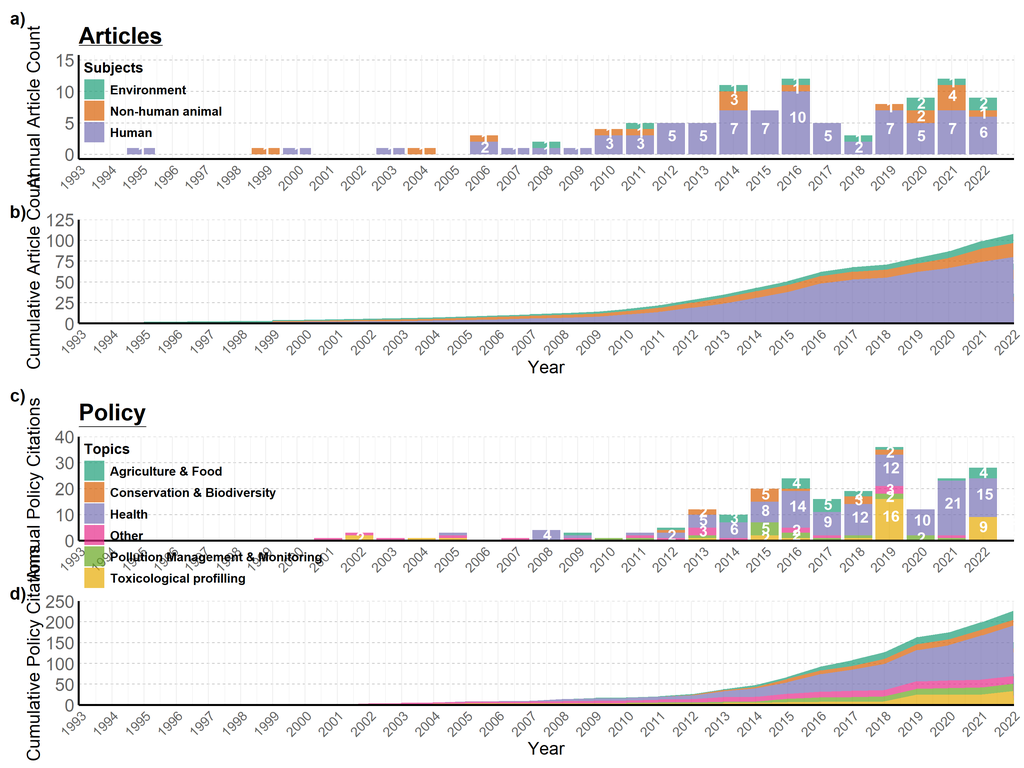

```r
# Join the study and subject datasets
sd_sub <- left_join(sd, sub, by = "study_id")

# Count the number of publications per year and calculate cumulative sum
sd1 <- sd %>%
  count(publication_year) %>%
  mutate(n_cumulative = cumsum(n))

# Custom theme ensuring consistent formatting
theme_count <- function() {
  theme_minimal() +
    theme(
      panel.grid.major.y = element_line(color = "gray", linetype = "dashed"),
      panel.grid.minor.y = element_blank(),
      axis.line.x      = element_line(size = 1.2),
      axis.line.y      = element_line(size = 1.2),
      axis.title.x     = element_text(size = 20),
      axis.title.y     = element_text(size = 20),
      axis.text.x      = element_text(angle = 45, hjust = 1,
                                      size = 15, color = "#666666"),
      axis.text.y      = element_text(size = 20, color = "#666666"),
      legend.position  = "none",
      # ⇩ Tag styling added here
      plot.tag         = element_text(size = 20, face = "bold")
    )
}

# Set fixed year range
min_year <- 1993
max_year <- 2022

fig1a <- sd_sub %>%
  mutate(subjects = strsplit(subject, ",\\s+")) %>%
  unnest(subjects) %>%
  count(publication_year, subjects) %>%
  group_by(subjects = reorder(subjects, n)) %>%
  ggplot(aes(x = publication_year, y = n, fill = subjects)) +
  geom_bar(stat = "identity", position = "stack", alpha = 0.7) +
  geom_text(
    aes(label = n),
    position = position_stack(vjust = 0.6),
    fontface = "bold",
    color = "white",
    size = 6,
    hjust = 0.4
  ) +
  scale_x_continuous(
    breaks = seq(min_year, max_year, by = 1),
    limits = c(min_year, max_year + 1),  # Add 1 year beyond max_year
    expand = expansion(0, 0)            # No extra gap at edges
  ) +
  scale_y_continuous("Annual Article Count", limits = c(0, 15)) +
  # Use plotmath expression to make the title bold and underlined
  labs(
    title = expression(bold(underline("Articles"))),
    y = "Article Count",
    tag = "a)",
    fill = "Subjects"
  ) +
  theme_count() +
  theme(
    # Make title bigger
    plot.title = element_text(size = 26),
    axis.title.x = element_blank(),
    legend.position = c(0, 1),
    legend.justification = c(0, 1),
    legend.box.just = "left",
    legend.text = element_text(size = 14, face = "bold"),
    legend.title = element_text(size = 16, face = "bold")
  ) +
  scale_fill_brewer(palette = "Dark2") +
  guides(
    fill = guide_legend(
      title = "Subjects",
      override.aes = list(alpha = 0.7, size = 8)
    )
  )

# Create the cumulative count plot for articles (fig1b) - Hides legend
fig1b <- sd_sub %>%
  mutate(subjects = strsplit(subject, ",\\s+")) %>%
  unnest(subjects) %>%
  count(publication_year, subjects) %>%
  group_by(subjects = reorder(subjects, n)) %>%
  mutate(n_cumulative = cumsum(n)) %>%
  ggplot(aes(x = publication_year, y = n_cumulative, fill = subjects)) +
  geom_area(size = 1.2, alpha = 0.7) +  # Ensuring consistent alpha
  scale_y_continuous("Cumulative Article Count", limits = c(0, 125), expand = expansion(0, 0)) +
  scale_x_continuous(
    breaks = seq(min(sd_sub$publication_year), max(sd_sub$publication_year), by = 1),
    expand = expansion(0,0)
  ) +
  labs(x = "Year", y = "Cumulative Article Count", tag = "b)") +
  theme_count() +
  scale_fill_brewer(palette = "Dark2") +
  theme(
    legend.position = "none"  # Remove legend from this plot
  )

fig1c <- ggplot(
  pol %>%
    filter(!is.na(policy_title)) %>%
    mutate(policy_topic = strsplit(policy_topic, ";\\s+")) %>%
    unnest(policy_topic) %>%
    group_by(policy_topic) %>%
    mutate(total_count = n()) %>%
    ungroup() %>%
    mutate(policy_topic = if_else(total_count < 7, "Other", policy_topic)) %>%
    filter(policy_year <= 2023) %>%
    count(policy_year, policy_topic) %>%
    complete(
      policy_year = 1993:2022,
      policy_topic = unique(policy_topic),
      fill = list(n = 0)
    ),
  aes(x = policy_year, y = n, fill = policy_topic)
) +
  geom_bar(stat = "identity", position = "stack", alpha = 0.7) +
  geom_text(
    aes(label = ifelse(n > 1, n, "")),
    position = position_stack(vjust = 0.6),
    fontface = "bold",
    color = "white",
    size = 6,
    hjust = 0.4
  ) +
  scale_x_continuous(
    breaks = 1993:2022,
    limits = c(1993, 2023),
    expand = expansion(0, 0)
  ) +
  scale_y_continuous(
    "Annual Policy Citations",
    limits = c(0, 40),
    expand = expansion(0, 0)
  ) +
  labs(
    # Use plotmath expression here as well
    title = expression(bold(underline("Policy"))),
    x = "Year",
    y = "Annual Policy Citations",
    tag = "c)",
    fill = "Policy Topics"
  ) +
  theme_count() +
  scale_fill_brewer(palette = "Dark2") +
  theme(
    # Make title bigger
    plot.title = element_text(size = 26),
    axis.title.x = element_blank(),
    legend.position = c(0.0, 1),
    legend.justification = c(0, 1),
    legend.box.just = "left",
    legend.text = element_text(size = 14, face = "bold"),
    legend.title = element_text(size = 16, face = "bold")
  ) +
  guides(
    fill = guide_legend(
      title = "Topics",
      override.aes = list(alpha = 0.7, size = 8)
    )
  )

# Create fig1d
fig1d <- pol %>%
  filter(!is.na(policy_title)) %>%
  mutate(policy_topic = strsplit(policy_topic, ";\\s+")) %>%
  unnest(policy_topic) %>%
  group_by(policy_topic) %>%
  mutate(total_count = n()) %>%
  ungroup() %>%
  mutate(policy_topic = if_else(total_count < 7, "Other", policy_topic)) %>%
  filter(policy_year < 2023) %>%
  count(policy_year, policy_topic) %>%
  complete(
    policy_year = 1993:2022,
    policy_topic = unique(policy_topic),
    fill = list(n = 0)
  ) %>%
  group_by(policy_topic) %>%
  arrange(policy_year, .by_group = TRUE) %>%
  mutate(n_cumulative = cumsum(n)) %>%
  ungroup() %>%
  ggplot(aes(x = policy_year, y = n_cumulative, fill = policy_topic)) +
  geom_area(size = 1.2, alpha = 0.7) +
  scale_y_continuous(
    "Cumulative Policy Citations",
    limits = c(0, 250),
    expand = expansion(0, 0)
  ) +
  scale_x_continuous(
    breaks = 1993:2022,
    expand = expansion(0, 0)
  ) +
  labs(
    x = "Year",
    y = "Cumulative Policy Citations",
    tag = "d)"
  ) +
  theme_count() +
  scale_fill_brewer(palette = "Dark2") +
  theme(
    legend.position = "none"
  )

# Combine plots.
fig1 <- fig1a / fig1b / fig1c / fig1d

# Display the final combined plot
fig1
```

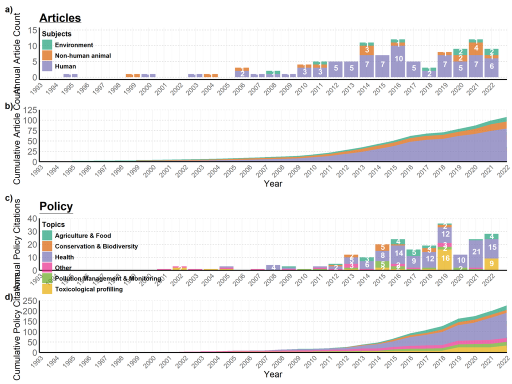

```r
# Save the final figure
ggsave(
  here("figures", "fig1.pdf"),
  width = 16, height = 24, units = "cm",
  scale = 2, dpi = 800
)

# Combine plots, ensuring the legend only appears in fig1a
fig1 <- fig1a / fig1b / fig1c / fig1d

# Display the final combined plot
fig1
```

```r
# Save the final figure
# ggsave(here("figures", "fig1.pdf"), width = 16, height = 24, units = "cm", scale = 2, dpi = 800)
# ggsave(here("figures", "fig1.svg"), width = 16, height = 24, units = "cm", scale = 2, dpi = 800)
```

## Policy country bar plot

```r
policy_country <- ggplot(
  pol %>%
    # 1) Remove rows with NA policy_title
    filter(!is.na(policy_title)) %>%
    # 2) Split multi-country strings on semicolon and unnest
    mutate(policy_country = strsplit(policy_country, ";\\s+")) %>%
    unnest(policy_country) %>%
    # 3) Lump any country used fewer than 7 times overall
    group_by(policy_country) %>%
    mutate(total_count = n()) %>%
    ungroup() %>%
    mutate(policy_country = if_else(total_count < 5, "Other", policy_country)) %>%
    # 4) Keep only years <= 2023
    filter(policy_year <= 2023) %>%
    # 5) Count number of policies per (year, country)
    count(policy_year, policy_country) %>%
    # 6) Complete missing (year, country) combos from 1993 to 2022 with n = 0
    complete(
      policy_year = 1993:2022,
      policy_country = unique(policy_country),
      fill = list(n = 0)
    ),
  aes(x = policy_year, y = n, fill = policy_country)
) +
  geom_bar(stat = "identity", position = "stack", alpha = 0.7) +
  geom_text(
    aes(label = ifelse(n > 0, n, "")),
    position = position_stack(vjust = 0.6),
    fontface = "bold", color = "white", size = 6, hjust = 0.4
  ) +
  scale_x_continuous(
    breaks = 1993:2022,
    limits = c(1993, 2023),
    expand = expansion(0, 0)
  ) +
  scale_y_continuous(
    "Annual Policy Citations",
    limits = c(0, 40),      # Adjust if you want a different max on the y-axis
    expand = expansion(0, 0)
  ) +
  labs(
    x = "Year",
    y = "Annual Policy Citations",
    fill = "Policy Countries"
  ) +
  theme_count() +
  scale_fill_brewer(palette = "Dark2") +
  theme(
    axis.title.x = element_blank(),
    legend.position = c(0.0, 1),   # Top-left
    legend.justification = c(0, 1),
    legend.box.just = "left"
  ) +
  guides(
    fill = guide_legend(
      title = "Policy Countries",
      override.aes = list(alpha = 0.7, size = 8)
    )
  )

df_distinct_count <- pol %>%
  distinct(policy_title, policy_year) %>%
  nrow()

df_distinct_count
```

```
## [1] 173
```

```r
# ggsave(here("figures", "policy_country.pdf"), width = 16, height = 10, units = "cm", scale = 2, dpi = 800)
# ggsave(here("figures", "policy_country.svg"), width = 16, height = 10, units = "cm", scale = 2, dpi = 800)
```

Create a standard theme for the supplementary plots

```r
organochlorTHEME <- function() {
  theme_minimal() +
  theme(
    title = element_text(size = 30),
    axis.text.y = element_text(size = 30),
    axis.text.x = element_text(size = 20),
    axis.line.x = element_line(color = "gray", size = 3),
    axis.line.y = element_blank(),
    axis.ticks.x = element_blank(),
    axis.ticks.y = element_blank(),
    axis.title.x = element_blank(),
    axis.title.y = element_blank(),
    panel.grid.major.y = element_blank(),
    panel.grid.minor.y = element_blank(),
    plot.tag = element_text(face = "bold"),
    legend.position = "none")
}
```

## Alternative time trends

1. Bar chart showing the annual number of published meta-analyses synthesising research on the impacts of organochlorine pesticides.
2. Line graph showing the cumulative time trends of meta-analyses synthesising research on the impacts of organochlorine pesticides.

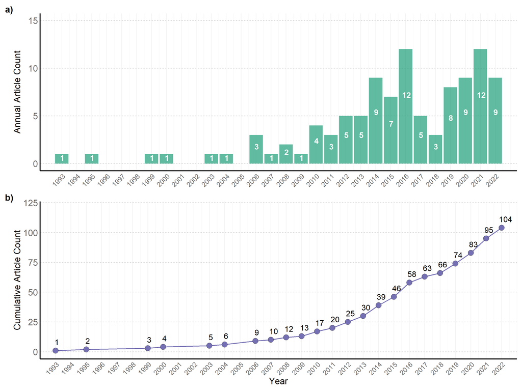

```r
# Create the annual Count Plot
annual_article_count <- sd1 %>%
  ggplot(aes(x = publication_year, y = n)) +
    geom_col(fill = "#1b9e77", alpha = 0.7) +
    geom_text(aes(label = n), position = position_stack(vjust = 0.6),
              fontface = "bold", color = "white", size = 6, hjust = 0.4) +
    scale_x_continuous(breaks = seq(min(sd1$publication_year), max(sd1$publication_year), by = 1),
                       expand = expansion(0,1)) +
    scale_y_continuous("Annual Article Count", limits = c(0,15)) +
    labs(x = "Year", tag = "a)") +
    theme_count() +
    theme(axis.title.x = element_blank())


# Create the cumulative Count Plot
cum_article_count <- sd1 %>%
  ggplot(aes(x = publication_year, y = n_cumulative)) +
    geom_line(color = "#7570b3", size = 1, linetype = "solid") +
    geom_point(shape = 21, size = 6, fill = "#7570b3", stroke = 0) +
    geom_text(aes(label = n_cumulative), hjust = 0.2, vjust = -1, size = 6, color = "black") +
    scale_x_continuous(breaks = seq(min(sd1$publication_year), max(sd1$publication_year), by = 1),
                       expand = expansion(0,1)) +
    scale_y_continuous("Cumulative Article Count", limits = c(0,120)) +
    labs(x = "Year", tag = "b)") +
    theme_count()

# Combine the two plots
alt_article_count <- annual_article_count / cum_article_count

alt_article_count
```

```r
# ggsave(here("figures", "alt_article_count.pdf"), width = 16, height = 12, units = "cm", scale = 2, dpi = 800)
# ggsave(here("figures", "alt_article_count.svg"), width = 16, height = 12, units = "cm", scale = 2, dpi = 800)
```

# Section 1

To evaluate the methodological quality and patterns of existing meta-analyses studying the effects of organochlorine pesticides.

## Figure 2

The methodological and reporting quality of meta-analyses according to CEESAT v. 2.1 (Woodcock et al., 2014). Scores are represented by the following colours: gold is regarded as the highest (best) score, green is second highest score, amber is second-lowest score, and red is the lowest (worst) score. The total counts of studies allocated to each score are shown in each bar. All CEESAT v. 2.1 items, along with our interpretation, are provided in Supplementary File 2.

## Figure 2a

CEESAT scores for 83 assessed meta-analyses

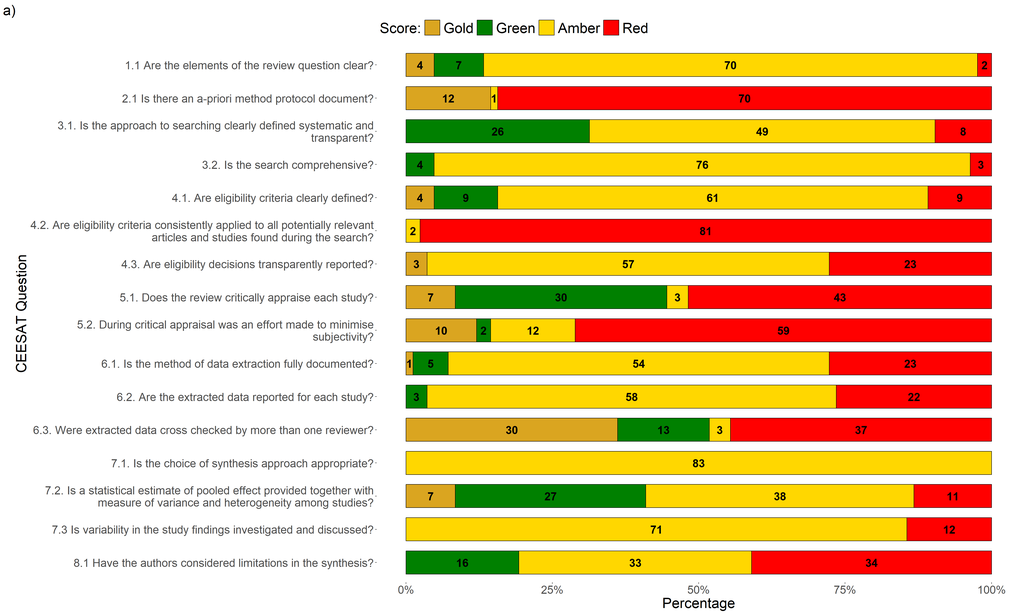

```r
# Start the data manipulation
percent_ceesat_score <- sd %>%
  filter(!is.na(author_year)) %>%
  select(studies = author_year, starts_with("CEE")) %>%
  na.omit() %>%
  pivot_longer(cols = -studies, names_to = "question", values_to = "score") %>%
  group_by(question, score) %>%
  summarise(n = n(), .groups = 'drop') %>%
  mutate(percent = (n/sum(n))*100,
         across(c(question, score), as.factor),
         question = fct_recode(question,
           `1.1 Are the elements of the review question clear?` = "CEESAT2_1.1",
           `2.1 Is there an a-priori method protocol document?` = "CEESAT2_2.1",
           `3.1. Is the approach to searching clearly defined systematic and\ntransparent?` = "CEESAT2_3.1",
           `3.2. Is the search comprehensive?` = "CEESAT2_3.2",
           `4.1. Are eligibility criteria clearly defined?` = "CEESAT2_4.1",
           `4.2. Are eligibility criteria consistently applied to all potentially relevant\narticles and studies found during the search?` = "CEESAT2_4.2",
           `4.3. Are eligibility decisions transparently reported?` = "CEESAT2_4.3",
           `5.1. Does the review critically appraise each study?` = "CEESAT2_5.1",
           `5.2. During critical appraisal was an effort made to minimise\nsubjectivity?` = "CEESAT2_5.2",
           `6.1. Is the method of data extraction fully documented?` = "CEESAT2_6.1",
           `6.2. Are the extracted data reported for each study?` = "CEESAT2_6.2",
           `6.3. Were extracted data cross checked by more than one reviewer?` = "CEESAT2_6.3",
           `7.1. Is the choice of synthesis approach appropriate?` = "CEESAT2_7.1",
           `7.2. Is a statistical estimate of pooled effect provided together with\nmeasure of variance and heterogeneity among studies?` = "CEESAT2_7.2",
           `7.3 Is variability in the study findings investigated and discussed?` = "CEESAT2_7.3",
           `8.1 Have the authors considered limitations in the synthesis?` = "CEESAT2_8.1"),
         question = factor(question, levels = rev(levels(question))),
         score = factor(score, levels = levels(score)[c(4,1,3,2)]))

# Create CEESAT plot
fig2a <- ggplot(data = percent_ceesat_score, aes(x = question, y = percent, fill = score)) +
  geom_col(width = 0.7, position = "fill", color = "black") +
  geom_text(aes(label = n), position = position_fill(vjust = 0.5), size = 7, fontface = "bold") +
  coord_flip() +
  guides(fill = guide_legend(reverse = TRUE)) +
  scale_fill_manual(values = c("#FF0000","#FFD700","#008000", "#DAA520"), name = "Score:") +
  scale_y_continuous(labels = scales::percent) +
  theme(panel.grid.major = element_blank(),
        panel.grid.minor = element_blank(),
        panel.background = element_blank(),
        axis.text.y = element_text(size = 20),
        axis.text.x = element_text(size = 20),
        axis.title.x = element_text(size = 25),
        axis.title.y = element_text(size = 25),
        legend.position = "top",
        legend.justification = "left",
        legend.direction = "horizontal",
        legend.box = "horizontal",
        legend.box.just = "left",
        legend.title.align = 0.5,
        legend.key.size = unit(1, "cm"),
        legend.title = element_text(size =25),
        legend.text = element_text(size = 25),
        strip.text = element_text(size = 20),
        strip.background = element_blank(),
        plot.tag = element_text(size = 25)) +
  ylab("Percentage") +
  xlab("CEESAT Question") +
  labs(tag = "a)")

fig2a
```

```r
total_n <- sum(percent_ceesat_score$n)
percentages <- tibble(
  red_percentage = sum(percent_ceesat_score$n[percent_ceesat_score$score == "Red"]) / total_n * 100,
  amber_percentage = sum(percent_ceesat_score$n[percent_ceesat_score$score == "Amber"]) / total_n * 100,
  green_percentage = sum(percent_ceesat_score$n[percent_ceesat_score$score == "Green"]) / total_n * 100,
  gold_percentage = sum(percent_ceesat_score$n[percent_ceesat_score$score == "Gold"]) / total_n * 100
)

 percentages
```

```
## # A tibble: 1 × 4
##   red_percentage amber_percentage green_percentage gold_percentage
##            <dbl>            <dbl>            <dbl>           <dbl>
## 1           32.9             50.5             10.7            5.87
```

```r
# ggsave(here("figures", "fig2a.pdf"), width = 25, height = 15, units = "cm", scale = 2, dpi = 800)
# ggsave(here("figures", "fig2a.svg"), width = 25, height = 15, units = "cm", scale = 2, dpi = 800)
```

Making the CEESAT question groups for result reporting

```r
# Create new categories for specified questions in numerical order
percent_ceesat_score$combined_category <- ifelse(
  grepl("^1\\.1", percent_ceesat_score$question) | grepl("^2\\.1", percent_ceesat_score$question),
  "Study Question",
  ifelse(grepl("^3\\.1", percent_ceesat_score$question) | grepl("^3\\.2", percent_ceesat_score$question),
    "Literature Searching",
    ifelse(grepl("^4\\.1", percent_ceesat_score$question) | grepl("^4\\.2", percent_ceesat_score$question) | grepl("^4\\.3", percent_ceesat_score$question),
      "Literature Screening",
      ifelse(grepl("^5\\.1", percent_ceesat_score$question) | grepl("^5\\.2", percent_ceesat_score$question) |
             grepl("^6\\.1", percent_ceesat_score$question) | grepl("^6\\.2", percent_ceesat_score$question) | grepl("^6\\.3", percent_ceesat_score$question),
        "Data Extraction",
        ifelse(grepl("^7", percent_ceesat_score$question), "Data Analysis",
          ifelse(grepl("^8", percent_ceesat_score$question), "Study Limitations", "Other"))))))

# Group by combined_category and score, then summarize
percent_ceesat_score_grouped <- percent_ceesat_score %>%
  group_by(combined_category, score) %>%
  summarise(total_n = sum(n))

# Calculate the total count for each special category
total_counts <- percent_ceesat_score_grouped %>%
  group_by(combined_category) %>%
  summarise(total_count = sum(total_n))

# Join total counts with grouped data
percent_ceesat_score_grouped <- left_join(percent_ceesat_score_grouped, total_counts, by = "combined_category")

# Add a column for relative percent
percent_ceesat_score_grouped <- percent_ceesat_score_grouped %>%
  mutate(relative_percent = (total_n / total_count) * 100)

print(percent_ceesat_score_grouped)
```

```
## # A tibble: 22 × 5
## # Groups:   combined_category [6]
##    combined_category    score total_n total_count relative_percent
##    <chr>                <fct>   <int>       <int>            <dbl>
##  1 Data Analysis        Red        23         249             9.24
##  2 Data Analysis        Amber     192         249            77.1
##  3 Data Analysis        Green      27         249            10.8
##  4 Data Analysis        Gold        7         249             2.81
##  5 Data Extraction      Red       184         415            44.3
##  6 Data Extraction      Amber     130         415            31.3
##  7 Data Extraction      Green      53         415            12.8
##  8 Data Extraction      Gold       48         415            11.6
##  9 Literature Screening Red       113         249            45.4
## 10 Literature Screening Amber     120         249            48.2
## # ℹ 12 more rows
```

```r
# view(percent_ceesat_score_grouped)
```

Calculating altmetric for each study

```r
# load data
bib_alt <- read_csv(here("data","scopus.csv"))

# function getAltmetrics(), the only parameter is doi; see example below
getAltmetrics <- function(doi = NULL,
                          foptions = list(),
                           ...) {
    if (!is.null(doi)) doi <- stringr::str_c("doi/", doi)
    identifiers <- purrr::compact(list(doi))
    if (!is.null(identifiers)) {
      ids <- identifiers[[1]]
    }
    base_url <- "http://api.altmetric.com/v1/"
    #request <- httr::GET(paste0(base_url, ids), httr::add_headers("user-agent" = "#rstats rAltmertic package https://github.com/ropensci/rAltmetric"))
    request <- httr::GET(paste0(base_url, ids))
    results <-
      jsonlite::fromJSON(httr::content(request, as = "text"), flatten = TRUE)
    results <- rlist::list.flatten(results)
    class(results) <- "altmetric"
    results
}
altmetric.crawler <- list(NULL)
for (n in 1:length(bib_alt$DOI)) {
 # format altmetric object
  format.Altmetric <- function(altmetric.object) {
  stats <- altmetric.object[grep("^cited", names(altmetric.object))]
  stats <- data.frame(stats, stringsAsFactors = FALSE)
  data.frame(paper_title = altmetric.object$title,
             journal = altmetric.object$journal,
             doi = altmetric.object$doi,
             #subject = altmetric.object$subjects,
             Altmetric.score = altmetric.object$score,
             stats = stats)
}
   # JASON formate
  altmetric.crawler[[n]]  <-  try(list(format.Altmetric(getAltmetrics(doi = bib_alt$DOI[n])))) # https://stackoverflow.com/questions/14059657/how-to-skip-an-error-in-a-loop?rq=1

  # create a dataframe function
  altmetric_df <- function(altmetric.object) {
  df <- data.frame(t(unlist(altmetric.object)), stringsAsFactors = FALSE)
  }
  #altmetric.crawler[[n]]  <-  try(list(altmetric_df(getAltmetrics(doi = DOIs[n]))))
  # create a function to summarize Altmetric object
  summary.altmetric <- function(x, ...) {
  if (inherits(x, "altmetric"))  {
string <- "Altmetrics on: \"%s\" with altmetric_id: %s published in %s."
vals   <- c(x$title,  x$altmetric_id, x$journal)
 if("journal" %in% names(x)) {
  cat(do.call(sprintf, as.list(c(string, vals))))
 } else {
   string <- "Altmetrics on: \"%s\" with altmetric_id: %s"
   cat(do.call(sprintf, as.list(c(string, vals))))
 }
  cat("\n")
  stats <- x[grep("^cited", names(x))]
  stats <- data.frame(stats, stringsAsFactors = FALSE)
  print(data.frame(stats = t(stats)))
  }
}
  # crawl
 # altmetric.crawler[[n]] <- try(list(summary.altmetric(getAltmetrics(doi = DOIs[n]))))
}
```

[output not shown]

```r
# save results from altmetric.crawler and retrieve lists within lists
altmetric.crawler2 <- sapply(altmetric.crawler, function(x) {x})
# retrieve stats
altmetric.summary <- data.frame(paper_title = sapply(altmetric.crawler2, function(x)  ifelse(class(x) == "data.frame",x$paper_title,NA)),
           journal = sapply(altmetric.crawler2, function(x) ifelse(class(x) == "data.frame",x$journal,NA)),
           doi = sapply(altmetric.crawler2, function(x) ifelse(class(x) == "data.frame",x$doi,NA)),
           #subject = sapply(altmetric.crawler2, function(x) ifelse(class(x) == "data.frame",x$subject,NA)),
           Altmetric.score = sapply(altmetric.crawler2, function(x) ifelse(class(x) == "data.frame",x$Altmetric.score,0)),
           policy = sapply(altmetric.crawler2, function(x) ifelse(class(x) == "data.frame",ifelse(!is.null(x$stats.cited_by_policies_count),x$stats.cited_by_policies_count,0),0)),
           patent = sapply(altmetric.crawler2, function(x) ifelse(class(x) == "data.frame",ifelse(!is.null(x$stats.cited_by_patents_count),x$stats.cited_by_patents_count,0),0))
           )
# Adding new columns to bib_alt dataframe
bib_alt <- bib_alt %>%
   mutate(Altmetric.score = altmetric.summary$Altmetric.score,
          policy = altmetric.summary$policy,
          patent = altmetric.summary$patent)

# Defining the scoring function
score <- function(x) {
  case_when(
    x == 'Red' ~ 0,
    x == 'Amber' ~ 1,
    x == 'Green' ~ 3,
    x == 'Gold' ~ 4,
    TRUE ~ NA_real_
  )
}
# Apply the scoring function across all columns starting with "CEESAT"
sd <- sd %>%
  mutate(across(starts_with("CEESAT"), score, .names = "points_{.col}"))
# Sum all the points columns to create a 'total_points' column
sd <- sd %>%
  mutate(total_points = rowSums(select(., starts_with("points_")), na.rm = TRUE))
```

## Figure 2b

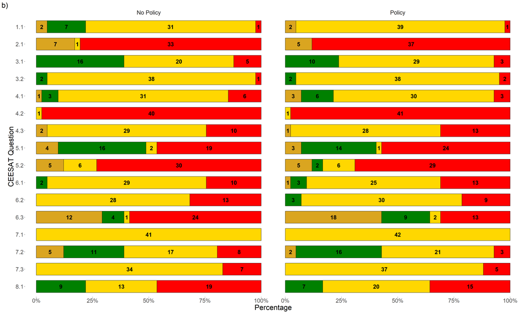

```r
# Converting policy to binary and dropping NAs
sd_bib_alt_policy <- left_join(sd, pol, join_by("author_year"), multiple = "all")

sd_bib_alt_policy <- sd_bib_alt_policy %>%
  # Ensure only unique author_year entries are kept
  distinct(author_year, .keep_all = TRUE) %>%

  # Create a new column categorizing policy presence
  mutate(
    policy_status = case_when(
      is.na(policy_title) ~ "No Policy",   # If missing (NA), classify as "No Policy"
      policy_title == "no policy" ~ "No Policy",  # If explicitly "no policy", classify as "No Policy"
      TRUE ~ "Policy"   # Everything else is considered a policy document
    )
  )

percent_ceesat_score1 <- sd_bib_alt_policy %>%
  filter(!is.na(author_year)) %>%
  select(studies = author_year, policy_status, starts_with("CEE")) %>%
  na.omit() %>%
  pivot_longer(cols = -c(studies, policy_status), names_to = "question", values_to = "score") %>%
  group_by(policy_status, question, score) %>%
  summarise(n = n(), .groups = 'drop') %>%
  mutate(percent = (n/sum(n))*100,
         across(c(question, score), as.factor),
         question = fct_recode(question,
           `1.1` = "CEESAT2_1.1",
           `2.1` = "CEESAT2_2.1",
           `3.1` = "CEESAT2_3.1",
           `3.2` = "CEESAT2_3.2",
           `4.1` = "CEESAT2_4.1",
           `4.2` = "CEESAT2_4.2",
           `4.3` = "CEESAT2_4.3",
           `5.1` = "CEESAT2_5.1",
           `5.2` = "CEESAT2_5.2",
           `6.1` = "CEESAT2_6.1",
           `6.2` = "CEESAT2_6.2",
           `6.3` = "CEESAT2_6.3",
           `7.1` = "CEESAT2_7.1",
           `7.2` = "CEESAT2_7.2",
           `7.3` = "CEESAT2_7.3",
           `8.1` = "CEESAT2_8.1"),
         question = factor(question, levels = rev(levels(question))),
         score = factor(score, levels = levels(score)[c(4,1,3,2)]))


fig2b <- ggplot(data = percent_ceesat_score1, aes(x = question, y = percent, fill = score)) +
  geom_col(width = 0.7, position = "fill", color = "black") +
  geom_text(aes(label = n), position = position_fill(vjust = 0.5), size = 7, fontface = "bold") +
  coord_flip() +
  guides(fill = guide_legend(reverse = TRUE)) +
  scale_fill_manual(values = c("#FF0000","#FFD700","#008000", "#DAA520"), name = "Score:") +
  scale_y_continuous(labels = scales::percent) +
  theme(panel.grid.major = element_blank(),
        panel.grid.minor = element_blank(),
        panel.background = element_blank(),
        axis.text.y = element_text(size = 20),
        axis.text.x = element_text(size = 20),
        axis.title.x = element_text(size = 25),
        axis.title.y = element_text(size = 25),
        legend.position = "none",
        strip.text = element_text(size = 20),
        strip.background = element_blank(),
        plot.tag = element_text(size = 25)) +
  ylab("Percentage") +
  xlab("CEESAT Question") +
  facet_wrap(~policy_status) +
  labs(tag = "b)")

fig2b
```

```r
# ggsave(here("figures", "fig2b.pdf"), width = 25, height = 15, units = "cm", scale = 2, dpi = 800)
# ggsave(here("figures", "fig2b.svg"), width = 25, height = 15, units = "cm", scale = 2, dpi = 800)


policy <- sd_bib_alt_policy$total_points[sd_bib_alt_policy$policy_status == "Policy"]
not_policy <- sd_bib_alt_policy$total_points[sd_bib_alt_policy$policy_status == "No Policy"]


# Create a tibble for policy values
policy_df <- tibble(
  values = policy,
  category = "Policy"
)

# Create a tibble for not_policy values
not_policy_df <- tibble(
  values = not_policy,
  category = "No Policy"
)

# Combine both tibbles into one
policy_combined <- bind_rows(policy_df, not_policy_df)

# View the combined tibble
print(policy_combined)
```

```
## # A tibble: 104 × 2
##    values category
##     <dbl> <chr>
##  1     13 Policy
##  2     21 Policy
##  3     21 Policy
##  4      0 Policy
##  5     15 Policy
##  6     17 Policy
##  7      3 Policy
##  8     16 Policy
##  9     17 Policy
## 10     14 Policy
## # ℹ 94 more rows
```

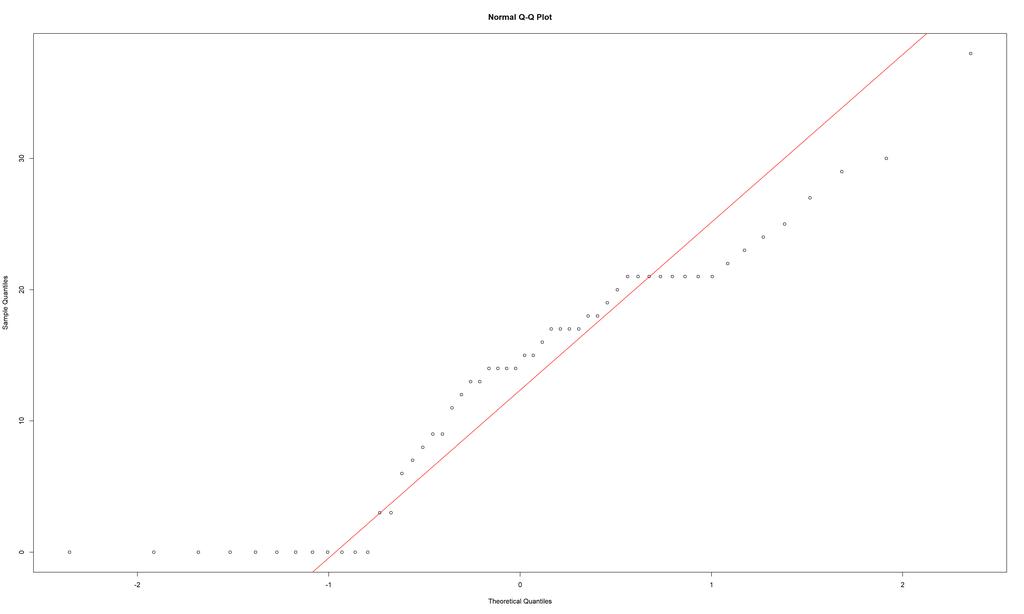

```r
# QQ Plot
qqnorm(policy)
qqline(policy, col = "red")
```

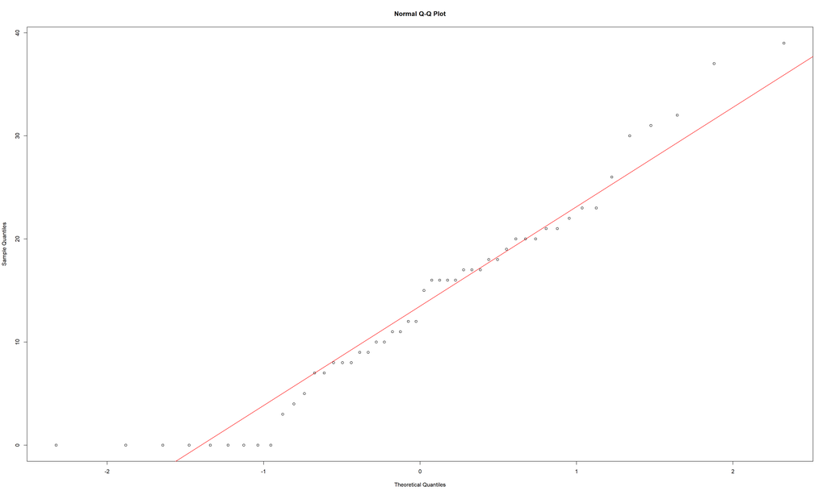

```r
# QQ Plot
qqnorm(not_policy)
qqline(not_policy, col = "red")
```

```r
policy_model <- clm(factor(values) ~ category, data=policy_combined)

summary(policy_model)
```

```
## formula: factor(values) ~ category
## data:    policy_combined
##
##  link  threshold nobs logLik  AIC    niter max.grad cond.H
##  logit flexible  104  -319.95 705.89 9(3)  1.88e-13 3.6e+03
##
## Coefficients:
##                Estimate Std. Error z value Pr(>|z|)
## categoryPolicy  0.04169    0.34233   0.122    0.903
##
## Threshold coefficients:
##       Estimate Std. Error z value
## 0|3   -1.35344    0.29825  -4.538
## 3|4   -1.18322    0.28830  -4.104
## 4|5   -1.12985    0.28550  -3.957
## 5|6   -1.07791    0.28302  -3.809
## 6|7   -1.02728    0.28072  -3.659
## 7|8   -0.88221    0.27484  -3.210
## 8|9   -0.70142    0.26939  -2.604
## 9|10  -0.53123    0.26588  -1.998
## 10|11 -0.44908    0.26478  -1.696
## 11|12 -0.32855    0.26402  -1.244
## 12|13 -0.21044    0.26409  -0.797
## 13|14 -0.13264    0.26434  -0.502
## 14|15  0.02161    0.26450   0.082
## 15|16  0.13709    0.26458   0.518
## 16|17  0.33177    0.26631   1.246
## 17|18  0.61558    0.27217   2.262
## 18|19  0.78808    0.27719   2.843
## 19|20  0.87844    0.28036   3.133
## 20|21  1.07018    0.28876   3.706
## 21|22  1.65535    0.32417   5.106
## 22|23  1.80323    0.33560   5.373
## 23|24  2.05957    0.35928   5.732
## 24|25  2.15742    0.36963   5.837
## 25|26  2.26341    0.38154   5.932
## 26|27  2.37935    0.39567   6.013
## 27|29  2.50760    0.41270   6.076
## 29|30  2.65143    0.43346   6.117
## 30|31  3.00805    0.49400   6.089
## 31|32  3.24108    0.54172   5.983
## 32|37  3.53860    0.61348   5.768
## 37|38  3.95391    0.73682   5.366
## 38|39  4.65680    1.02117   4.560
```

```r
policy_model_sensitivity <- t.test(policy,not_policy)

policy_model_sensitivity
```

```
##
##  Welch Two Sample t-test
##
## data:  policy and not_policy
## t = -0.13057, df = 100.22, p-value = 0.8964
## alternative hypothesis: true difference in means is not equal to 0
## 95 percent confidence interval:
##  -4.114662  3.606514
## sample estimates:
## mean of x mean of y
##  13.42593  13.68000
```

## Figure 3a

Bar plot showing the percentage and total count of bias methodologies used in meta-analyses investigating the impacts of organochlorine pesticides. Note that some meta-analyses may contribute to multiple sections if the study involved the use of multiple bias assessment methodologies.

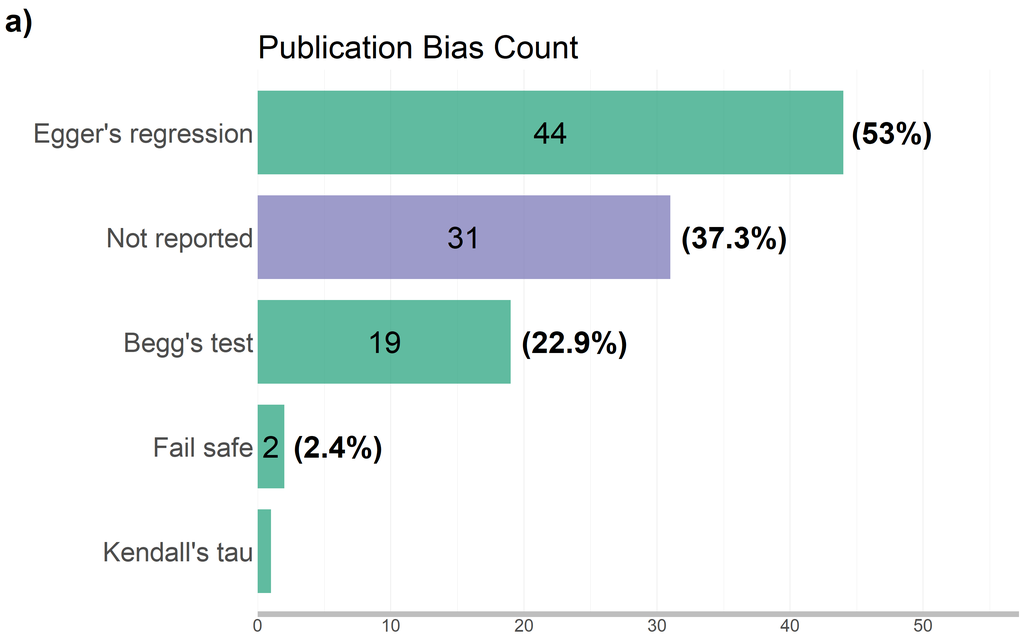

```r
# Calculate the total count for each category
bias_method_count <- sd %>%
  separate_rows(bias_assessment_method, sep = ",\\s+") %>%
  count(bias_assessment_method) %>%
  filter(bias_assessment_method != "NA") %>%
  group_by(bias_assessment_method) %>%
  summarise(n = sum(n))

# Calculate proportion and percentage
bias_method_pct <- bias_method_count %>%
  mutate(proportion = n / 83,
         percentage = proportion * 100)

# Create the bar plot
fig3a <- bias_method_count %>%
  ggplot(aes(x = n, y = reorder(bias_assessment_method, n),
             fill = ifelse(grepl("Not reported", bias_assessment_method), "#7370b3", "#1b9e77"))) +
  geom_bar(stat = "identity", width = 0.8, alpha = 0.7) +
  geom_text(aes(label = ifelse(n > 1, n, ""), x = n / 2), hjust = 0.5, size = 12, color = "black") +
  geom_text(data = bias_method_pct %>% filter(n > 1),
            aes(label = paste0("(", round(percentage, 1), "%)"), x = n),
            hjust = -0.1, size = 12, color = "black", fontface = "bold") +
  scale_fill_identity(guide = "none") +
  scale_x_continuous(expand = c(0, 0), limits = c(0, max(bias_method_count$n) * 1.3)) +
  labs(title = "Publication Bias Count", x = NULL, y = NULL, tag = "a)", size = 30) +
  organochlorTHEME()

fig3a
```

```r
# ggsave(here("figures", "fig3a.pdf"), width = 16, height = 10, units = "cm", scale = 2, dpi = 800)
# ggsave(here("figures", "fig3a.svg"), width = 16, height = 10, units = "cm", scale = 2, dpi = 800)
```

## Figure 3b

Bar plot showing the percentage and total count of heterogeneity assessment methods used in meta-analyses investigating the impacts of organochlorine pesticides. Note that some meta-analyses may contribute to multiple sections if the study involved multiple heterogeneity assessments. Percentage is showing the proportion of studies.

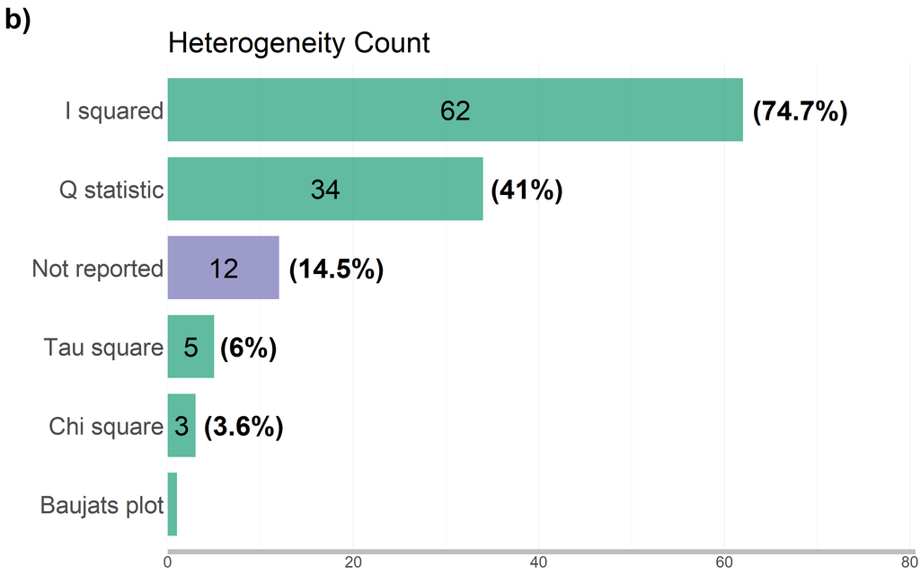

```r
# Figure 3b: Heterogeneity Assessment Methods
heterogeneity_count <- sd %>%
  separate_rows(heterogeneity_assessment_method, sep = ",\\s+") %>%
  count(heterogeneity_assessment_method) %>%
  filter(heterogeneity_assessment_method != "NA") %>%
  group_by(heterogeneity_assessment_method) %>%
  summarise(n = sum(n))

heterogeneity_pct <- heterogeneity_count %>%
  mutate(proportion = n / 83,
         percentage = proportion * 100)

fig3b <- heterogeneity_count %>%
  ggplot(aes(x = n, y = reorder(heterogeneity_assessment_method, n),
             fill = ifelse(grepl("Not reported", heterogeneity_assessment_method), "#7370b3", "#1b9e77"))) +
  geom_bar(stat = "identity", width = 0.8, alpha = 0.7) +
  geom_text(aes(label = ifelse(n > 1, n, ""), x = n / 2), hjust = 0.5, size = 12, color = "black") +
  geom_text(data = heterogeneity_pct %>% filter(n > 1),
            aes(label = paste0("(", round(percentage, 1), "%)"), x = n),
            hjust = -0.1, size = 12, color = "black", fontface = "bold") +
  scale_fill_identity(guide = "none") +
  scale_x_continuous(expand = c(0, 0), limits = c(0, max(heterogeneity_count$n) * 1.3)) +
  labs(title = "Heterogeneity Count", x = NULL, y = NULL, tag = "b)", size = 30) +
  organochlorTHEME()

fig3b
```

```r
# ggsave(here("figures", "fig3b.pdf"), width = 16, height = 10, units = "cm", scale = 2, dpi = 800)
# ggsave(here("figures", "fig3b.svg"), width = 16, height = 10, units = "cm", scale = 2, dpi = 800)
```

## Figure 3c

Bar plot showing the percentage and total count of sensitivity analyses conducted in meta-analyses investigating the impacts of organochlorine pesticides. Note that some meta-analyses may contribute to multiple sections if the study involved multiple sensitivity analyses.

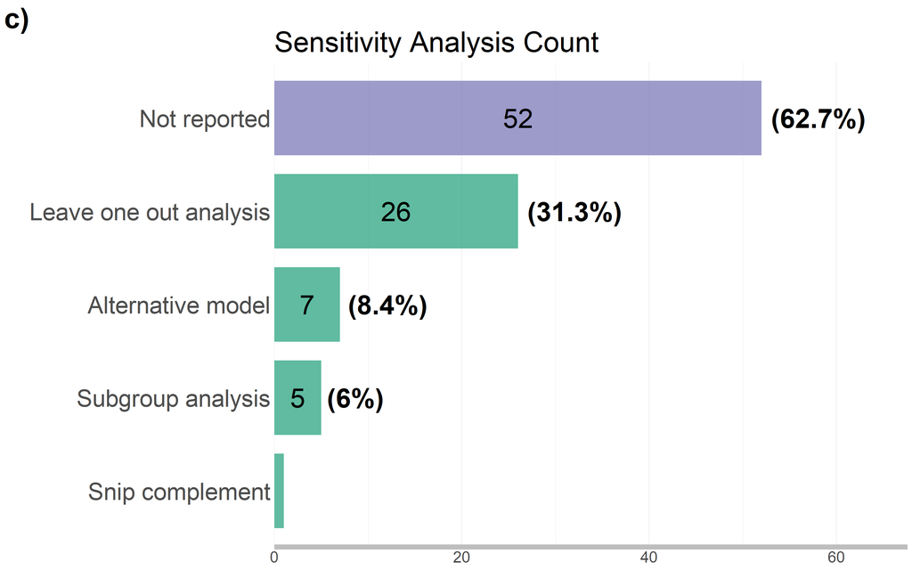

```r
# Figure 3c: Sensitivity Analysis Methods
sensitivity_count <- sd %>%
  separate_rows(sensitivity_analysis_method, sep = ",\\s+") %>%
  count(sensitivity_analysis_method) %>%
  filter(sensitivity_analysis_method != "NA") %>%
  group_by(sensitivity_analysis_method) %>%
  summarise(n = sum(n))

sensitivity_pct <- sensitivity_count %>%
  mutate(proportion = n / 83,
         percentage = proportion * 100)

fig3c <- sensitivity_count %>%
  ggplot(aes(x = n, y = reorder(sensitivity_analysis_method, n),
             fill = ifelse(grepl("Not reported", sensitivity_analysis_method), "#7370b3", "#1b9e77"))) +
  geom_bar(stat = "identity", width = 0.8, alpha = 0.7) +
  geom_text(aes(label = ifelse(n > 1, n, ""), x = n / 2), hjust = 0.5, size = 12, color = "black") +
  geom_text(data = sensitivity_pct %>% filter(n > 1),
            aes(label = paste0("(", round(percentage, 1), "%)"), x = n),
            hjust = -0.1, size = 12, color = "black", fontface = "bold") +
  scale_fill_identity(guide = "none") +
  scale_x_continuous(expand = c(0, 0), limits = c(0, max(sensitivity_count$n) * 1.3)) +
  labs(title = "Sensitivity Analysis Count", x = NULL, y = NULL, tag = "c)", size = 30) +
  organochlorTHEME()

fig3c
```

```r
# ggsave(here("figures", "fig3c.pdf"), width = 16, height = 10, units = "cm", scale = 2, dpi = 800)
# ggsave(here("figures", "fig3c.svg"), width = 16, height = 10, units = "cm", scale = 2, dpi = 800)
```

## Figure 3d

Bar plot showing the percentage and total count of reporting guidelines used in meta-analyses investigating the impacts of organochlorine pesticides. Note that some meta-analyses may contribute to multiple sections if the study involved the use of multiple reporting guidelines.

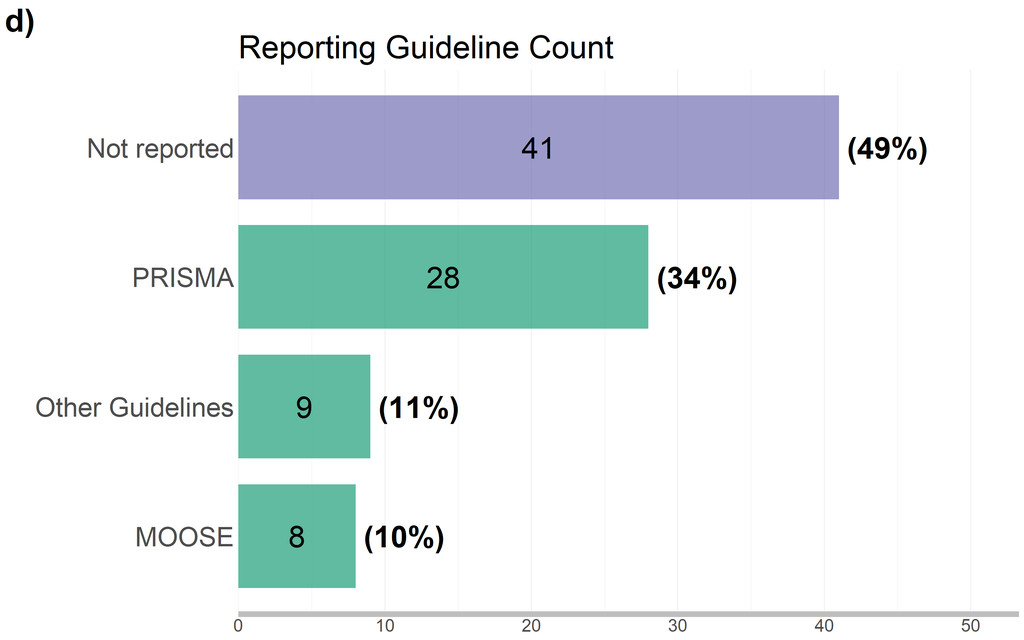

```r
# Figure 3d: Reporting Guidelines
reporting_guide_count <- sd %>%
  separate_rows(reporting_standards_type, sep = ",\\s+") %>%
  count(reporting_standards_type) %>%
  filter(reporting_standards_type != "NA") %>%
  mutate(reporting_standards_type = ifelse(n < 3, "Other Guidelines", as.character(reporting_standards_type))) %>%
  group_by(reporting_standards_type) %>%
  summarise(n = sum(n))

reporting_guide_pct <- reporting_guide_count %>%
  mutate(proportion = n / 83,
         percentage = proportion * 100)

fig3d <- reporting_guide_count %>%
  ggplot(aes(x = n, y = reorder(reporting_standards_type, n),
             fill = ifelse(grepl("Not reported", reporting_standards_type), "#7370b3", "#1b9e77"))) +
  geom_bar(stat = "identity", width = 0.8, alpha = 0.7) +
  geom_text(aes(label = ifelse(n > 1, n, ""), x = n / 2), hjust = 0.5, size = 12, color = "black") +
  geom_text(data = reporting_guide_pct %>% filter(n > 1),
            aes(label = paste0("(", round(percentage, 0), "%)"), x = n),
            hjust = -0.1, size = 12, color = "black", fontface = "bold") +
  scale_fill_identity(guide = "none") +
  scale_x_continuous(expand = c(0, 0), limits = c(0, max(reporting_guide_count$n) * 1.3)) +
  labs(title = "Reporting Guideline Count", x = "Count", y = NULL, tag = "d)", size = 30) +
  organochlorTHEME()

fig3d
```

```r
# ggsave(here("figures", "fig3d.pdf"), width = 16, height = 10, units = "cm", scale = 2, dpi = 800)
# ggsave(here("figures", "fig3d.svg"), width = 16, height = 10, units = "cm", scale = 2, dpi = 800)
```

## CEESAT reporting guideline

CEESAT scores for meta-analyses referencing a reporting guideline (right panel) and those not referencing a reporting guideline (left panel).

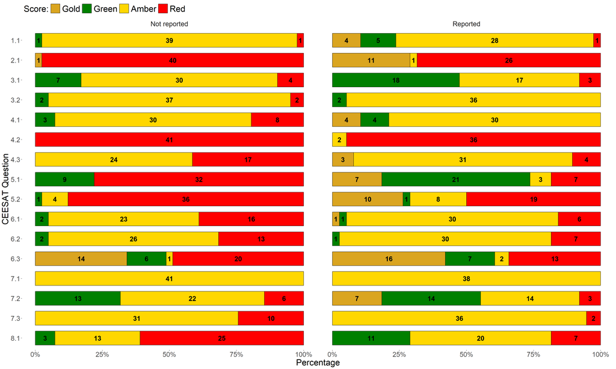

```r
sd_bib_alt_guideline <- sd %>%
  mutate(binary_guideline = if_else(reporting_standards_type == "Not reported", "Not reported", "Reported")) %>%
    drop_na(binary_guideline, total_points)

percent_ceesat_score2 <- sd_bib_alt_guideline %>%
  filter(!is.na(author_year)) %>%
  select(studies = author_year, binary_guideline, starts_with("CEE")) %>%
  na.omit() %>%
  pivot_longer(cols = -c(studies, binary_guideline), names_to = "question", values_to = "score") %>%
  group_by(binary_guideline, question, score) %>%
  summarise(n = n(), .groups = 'drop') %>%
  mutate(percent = (n/sum(n))*100,
         across(c(question, score), as.factor),
         question = fct_recode(question,
           `1.1` = "CEESAT2_1.1",
           `2.1` = "CEESAT2_2.1",
           `3.1` = "CEESAT2_3.1",
           `3.2` = "CEESAT2_3.2",
           `4.1` = "CEESAT2_4.1",
           `4.2` = "CEESAT2_4.2",
           `4.3` = "CEESAT2_4.3",
           `5.1` = "CEESAT2_5.1",
           `5.2` = "CEESAT2_5.2",
           `6.1` = "CEESAT2_6.1",
           `6.2` = "CEESAT2_6.2",
           `6.3` = "CEESAT2_6.3",
           `7.1` = "CEESAT2_7.1",
           `7.2` = "CEESAT2_7.2",
           `7.3` = "CEESAT2_7.3",
           `8.1` = "CEESAT2_8.1"),
         question = factor(question, levels = rev(levels(question))),
         score = factor(score, levels = levels(score)[c(4,1,3,2)]))

ceesat_report <- ggplot(data = percent_ceesat_score2, aes(x = question, y = percent, fill = score)) +
  geom_col(width = 0.7, position = "fill", color = "black") +
  geom_text(aes(label = n), position = position_fill(vjust = 0.5), size = 7, fontface = "bold") +
  coord_flip() +
  guides(fill = guide_legend(reverse = TRUE)) +
  scale_fill_manual(values = c("#FF0000","#FFD700","#008000", "#DAA520"), name = "Score:") +
  scale_y_continuous(labels = scales::percent) +
  theme(panel.grid.major = element_blank(),
        panel.grid.minor = element_blank(),
        panel.background = element_blank(),
        axis.text.y = element_text(size = 20),
        axis.text.x = element_text(size = 20),
        axis.title.x = element_text(size = 25),
        axis.title.y = element_text(size = 25),
        legend.position = "top",
        legend.justification = "left",
        legend.direction = "horizontal",
        legend.box = "horizontal",
        legend.box.just = "left",
        legend.title.align = 0.5,
        legend.key.size = unit(1, "cm"),
        legend.title = element_text(size =25),
        legend.text = element_text(size = 25),
        strip.text = element_text(size = 20),
        strip.background = element_blank()) +
  ylab("Percentage") +
  xlab("CEESAT Question") +
  facet_wrap(~binary_guideline)

ceesat_report
```

```r
# ggsave(here("figures", "ceesat_report.pdf"), width = 25, height = 15, units = "cm", scale = 2, dpi = 800)
# ggsave(here("figures", "ceesat_report.svg"), width = 25, height = 15, units = "cm", scale = 2, dpi = 800)

guideline <- sd_bib_alt_guideline$total_points[sd_bib_alt_guideline$binary_guideline == "Reported"]
no_guideline <- sd_bib_alt_guideline$total_points[sd_bib_alt_guideline$binary_guideline == "Not reported"]


# Create a tibble for policy values
guideline_df <- tibble(
  values = guideline,
  category = "Cited Guideline"
)

# Create a tibble for not_policy values
no_guideline_df <- tibble(
  values = no_guideline,
  category = "No Guideline"
)

# Combine both tibbles into one
guideline_combined <- bind_rows(guideline_df, no_guideline_df)

# View the combined tibble
print(guideline_combined)
```

```
## # A tibble: 79 × 2
##    values category
##     <dbl> <chr>
##  1      7 Cited Guideline
##  2     11 Cited Guideline
##  3     17 Cited Guideline
##  4     21 Cited Guideline
##  5     20 Cited Guideline
##  6     16 Cited Guideline
##  7     31 Cited Guideline
##  8     15 Cited Guideline
##  9     37 Cited Guideline
## 10     16 Cited Guideline
## # ℹ 69 more rows
```

```r
guideline_model <- clm(factor(values) ~ category, data=guideline_combined)

summary(guideline_model)
```

```
## formula: factor(values) ~ category
## data:    guideline_combined
##
##  link  threshold nobs logLik  AIC    niter max.grad cond.H
##  logit flexible  79   -239.91 543.82 7(0)  1.32e-10 1.1e+03
##
## Coefficients:
##                      Estimate Std. Error z value Pr(>|z|)
## categoryNo Guideline  -2.4120     0.4656   -5.18 2.22e-07 ***
## ---
## Signif. codes:  0 '***' 0.001 '**' 0.01 '*' 0.05 '.' 0.1 ' ' 1
##
## Threshold coefficients:
##       Estimate Std. Error z value
## 3|4    -5.4661     0.8159  -6.699
## 4|5    -5.0368     0.7056  -7.138
## 5|6    -4.7247     0.6429  -7.348
## 6|7    -4.4765     0.6018  -7.439
## 7|8    -3.9375     0.5328  -7.391
## 8|9    -3.5474     0.4963  -7.148
## 9|10   -3.1240     0.4646  -6.724
## 10|11  -2.9399     0.4524  -6.498
## 11|12  -2.6925     0.4375  -6.154
## 12|13  -2.4601     0.4241  -5.801
## 13|14  -2.3063     0.4149  -5.559
## 14|15  -2.0034     0.3959  -5.060
## 15|16  -1.7814     0.3818  -4.666
## 16|17  -1.4169     0.3588  -3.949
## 17|18  -0.9985     0.3371  -2.963
## 18|19  -0.7251     0.3270  -2.218
## 19|20  -0.5890     0.3235  -1.820
## 20|21  -0.3875     0.3212  -1.206
## 21|22   0.4028     0.3269   1.232
## 22|23   0.5959     0.3335   1.787
## 23|24   0.9087     0.3520   2.582
## 24|25   1.0256     0.3608   2.842
## 25|26   1.1529     0.3712   3.106
## 26|27   1.2894     0.3842   3.356
## 27|29   1.4373     0.4003   3.591
## 29|30   1.6001     0.4206   3.804
## 30|31   1.9927     0.4816   4.138
## 31|32   2.2427     0.5301   4.231
## 32|37   2.5566     0.6028   4.241
## 37|38   2.9876     0.7275   4.107
## 38|39   3.7056     1.0141   3.654
```

```r
t.test(guideline,no_guideline)
```

```
##
##  Welch Two Sample t-test
##
## data:  guideline and no_guideline
## t = 6.1128, df = 68.538, p-value = 5.269e-08
## alternative hypothesis: true difference in means is not equal to 0
## 95 percent confidence interval:
##   6.091412 11.994595
## sample estimates:
## mean of x mean of y
##  21.92105  12.87805
```

## Box ceesat scores

Box and violin plot showing the distribution of CEESAT scores for studies cited in policy documents and studies not cited in policy documents

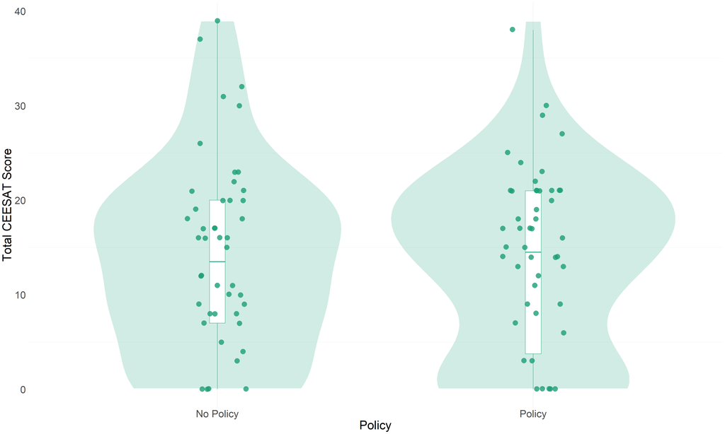

```r
box_ceesat <- policy_combined %>%
  ggplot(aes(x = category, y = values)) +
  geom_violin(fill = "#1b9e77", alpha =0.2, color = NA, trim = FALSE) +
  geom_boxplot(width = 0.05, fill = "white", color = "#1b9e77", outlier.shape = NA) +
  geom_jitter(width = 0.1, height = 0.05, color = "#1b9e77", alpha = 0.8, size = 6) +
  scale_y_continuous(limits = c(0, max(sd$total_points))) +
  labs( x = "Policy", y = "Total CEESAT Score") +
  theme_minimal() +
  theme(panel.grid.major.y = element_blank(),
        axis.line.y = element_blank(),
        axis.ticks.y = element_blank(),
        axis.text.x = element_text(size = 25),
        axis.text.y = element_text(size = 25),
        axis.title.x = element_text(size = 30),
        axis.title.y = element_text(size = 30),
        plot.title = element_blank())

box_ceesat
```

```r
# ggsave(here("figures", "box_ceesat.pdf"), width = 25, height = 15, units = "cm", scale = 2, dpi = 800)
# ggsave(here("figures", "box_ceesat.svg"), width = 25, height = 15, units = "cm", scale = 2, dpi = 800)
```

## Alluvial plot for bias assessment

Alluvial plot showing the relationship between the Journal Citation Report Category and bias assessment method.

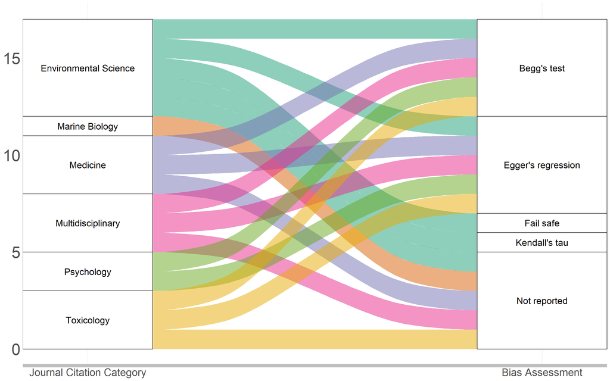

```r
# Data Transformation
bias_assessment_alluvial <- sd %>%
    separate_rows(bias_assessment_method, sep = ",\\s+") %>%
    separate_rows(Journal_Category_Allocated_Broad, sep = "/\\s+") %>%
    filter(!is.na(bias_assessment_method)) %>%
    group_by(Journal_Category_Allocated_Broad, bias_assessment_method) %>%
    count(bias_assessment_method, Journal_Category_Allocated_Broad) %>%
    summarise(freq = n(), .groups = 'drop') %>%
    group_by(bias_assessment_method)

# Create the Alluvial plot
alluvial_bias <- bias_assessment_alluvial %>%
  ggplot(aes(y = freq ,axis1 = Journal_Category_Allocated_Broad, axis2 = bias_assessment_method)) +
  scale_x_discrete(limits = c("Journal Citation Category", "Bias Assessment"), expand = c(.05, .05)) +
  xlab("Variables") +
  geom_alluvium(aes(fill = Journal_Category_Allocated_Broad)) +
  geom_stratum(width = 1/3.5, fill = "white", color = "black") +
  geom_text(stat = "stratum", aes(label = after_stat(stratum)), size = 6) +
  labs(x= "Variables", y = "Frequency", fill = "Journal Category Allocated") +
  scale_fill_brewer(palette = "Dark2") +
  organochlorTHEME()

alluvial_bias
```

```r
# ggsave(here("figures", "alluvial_bias.pdf"), width = 16, height = 10, units = "cm", scale = 2, dpi = 800)
# ggsave(here("figures", "alluvial_bias.jpg"), width = 16, height = 10, units = "cm", scale = 2, dpi = 800)
```

## Alluvial plot for Heterogeneity

Alluvial plot showing the relationship between the Journal Citation Report Category and heterogeneity assessment method.

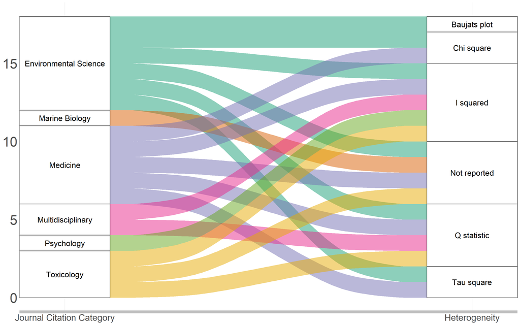

```r
# Data Transformation
heterogeneity_alluvial <- sd %>%
    separate_rows(heterogeneity_assessment_method, sep = ",\\s+") %>%
    separate_rows(Journal_Category_Allocated_Broad, sep = "/\\s+") %>%
    filter(!is.na(heterogeneity_assessment_method)) %>%
    group_by(Journal_Category_Allocated_Broad, heterogeneity_assessment_method) %>%
    count(heterogeneity_assessment_method, Journal_Category_Allocated_Broad) %>%
    summarise(freq = n(), .groups = 'drop') %>%
    group_by(heterogeneity_assessment_method)

# Create the Alluvial plot
alluvial_het <- heterogeneity_alluvial %>%
ggplot(aes(y = freq ,axis1 = Journal_Category_Allocated_Broad, axis2 = heterogeneity_assessment_method)) +
  scale_x_discrete(limits = c("Journal Citation Category", "Heterogeneity"), expand = c(.05, .05)) +
  xlab("Variables") +
  geom_alluvium(aes(fill = Journal_Category_Allocated_Broad)) +
  geom_stratum(width = 1/4.5, fill = "white", color = "black") +
  geom_text(stat = "stratum", aes(label = after_stat(stratum)), size = 6) +
  labs(x= "Variables", y = "Frequency", fill = "Journal Category Allocated") +
  scale_fill_brewer(palette = "Dark2") +
  organochlorTHEME()

alluvial_het
```

```r
# ggsave(here("figures", "alluvial_het.pdf"), width = 16, height = 10, units = "cm", scale = 2, dpi = 800)
# ggsave(here("figures", "alluvial_het.jpg"), width = 16, height = 10, units = "cm", scale = 2, dpi = 800)
```

## Figure s10

Alluvial plot showing the relationship between the Journal Citation Report Category and sensitivity analysis.

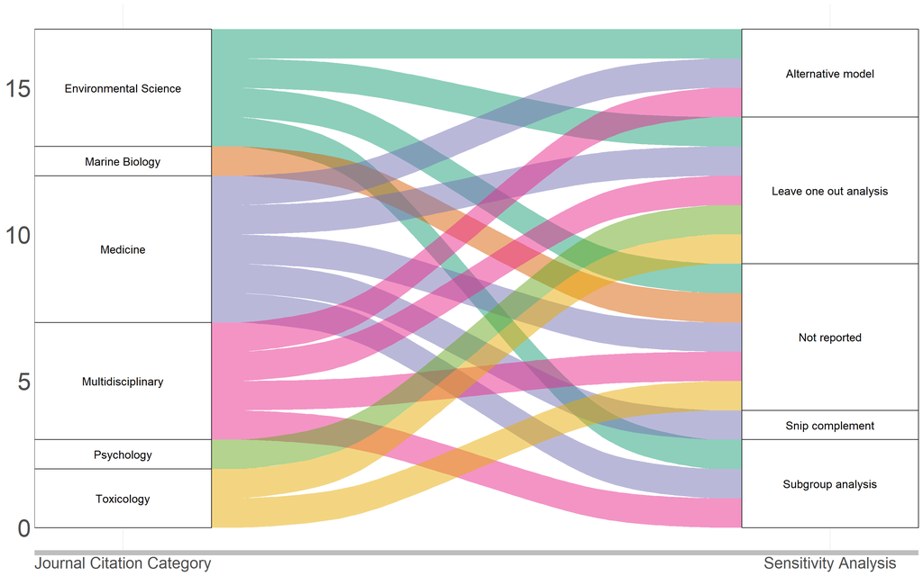

```r
# Data Transformation
sensitivity_analysis_alluvial <- sd %>%
    separate_rows(sensitivity_analysis_method, sep = ",\\s+") %>%
    separate_rows(Journal_Category_Allocated_Broad, sep = "/\\s+") %>%
    filter(!is.na(sensitivity_analysis_method)) %>%
    group_by(Journal_Category_Allocated_Broad, sensitivity_analysis_method) %>%
    count(sensitivity_analysis_method, Journal_Category_Allocated_Broad) %>%
    summarise(freq = n(), .groups = 'drop') %>%
    group_by(sensitivity_analysis_method)

# Create the Alluvial plot
alluvial_sens <- sensitivity_analysis_alluvial %>%
ggplot(aes(y = freq ,axis1 = Journal_Category_Allocated_Broad, axis2 = sensitivity_analysis_method)) +
  scale_x_discrete(limits = c("Journal Citation Category", "Sensitivity Analysis"), expand = c(.05, .05)) +
  xlab("Variables") +
  geom_alluvium(aes(fill = Journal_Category_Allocated_Broad)) +
  geom_stratum(width = 1/4, fill = "white", color = "black") +
  geom_text(stat = "stratum", aes(label = after_stat(stratum)), size = 5) +
  labs(x= "Variables", y = "Frequency", fill = "Journal Category Allocated") +
  scale_fill_brewer(palette = "Dark2") +
  organochlorTHEME()

alluvial_sens
```

```r
# ggsave(here("figures", "alluvial_sens.pdf"), width = 16, height = 10, units = "cm", scale = 2, dpi = 800)
# ggsave(here("figures", "alluvial_sens.jpg"), width = 16, height = 10, units = "cm", scale = 2, dpi = 800)
```

## Alluvial plot for reporting guideline

An alluvial plot showing the relationship between the Journal Citation Report Category and reporting guideline used

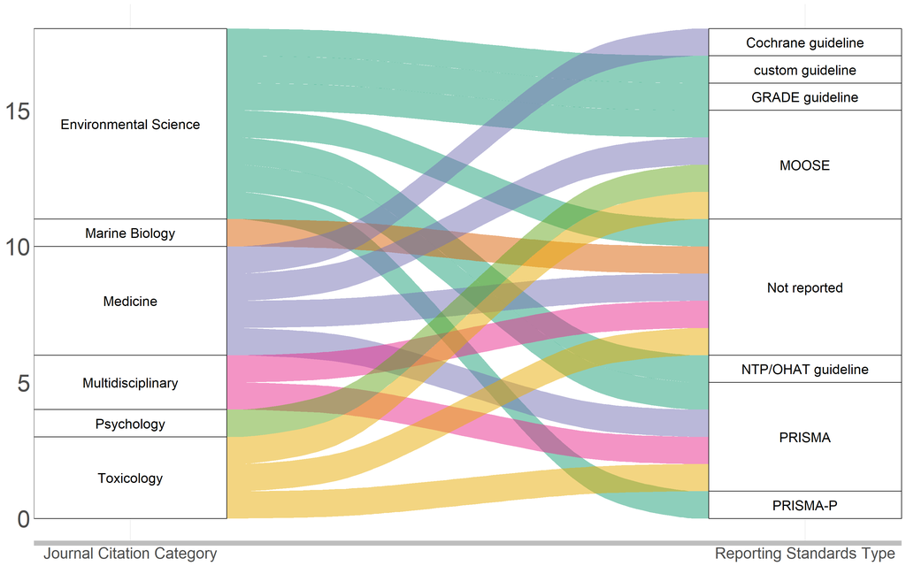

```r
# Data Transformation
reporting_standards_alluvial <- sd %>%
    separate_rows(reporting_standards_type, sep = ",\\s+") %>%
    separate_rows(Journal_Category_Allocated_Broad, sep = "/\\s+") %>%
    filter(!grepl("no category found", Journal_Category_Allocated_Broad, ignore.case = TRUE)) %>%
    filter(!is.na(reporting_standards_type)) %>%
    group_by(Journal_Category_Allocated_Broad, reporting_standards_type) %>%
    count(reporting_standards_type, Journal_Category_Allocated_Broad) %>%
    summarise(freq = n(), .groups = 'drop') %>%
    group_by(reporting_standards_type)

# Create the Alluvial plot
alluvial_report <- reporting_standards_alluvial %>%
ggplot( aes(y = freq ,axis1 = Journal_Category_Allocated_Broad, axis2 = reporting_standards_type)) +
  scale_x_discrete(limits = c("Journal Citation Category", "Reporting Standards Type"), expand = c(.05, .05)) +
  xlab("Variables") +
  geom_alluvium(aes(fill = Journal_Category_Allocated_Broad)) +
  geom_stratum(width = 1/3.5, fill = "white", color = "black") +
  labs(x= "Variables", y = "Frequency", fill = "Journal Category Allocated") +
  geom_text(stat = "stratum", aes(label = after_stat(stratum)), size = 6) +
    scale_fill_brewer(palette = "Dark2") +
  organochlorTHEME()

alluvial_report
```

```r
# ggsave(here("figures", "alluvial_report.pdf"), width = 16, height = 10, units = "cm", scale = 2, dpi = 800)
# ggsave(here("figures", "alluvial_report.jpg"), width = 16, height = 10, units = "cm", scale = 2, dpi = 800)
```

## Database bar plot

Bar plot showing the percentage and total count of scientific literature databases used in meta-analyses investigating the impacts of organochlorine pesticides. Note that some meta-analyses may contribute to multiple sections if the study involved multiple scientific literature databases. The “Other databases” category includes all databases with a count of 3 or less. Percentage is showing the proportion of studies.

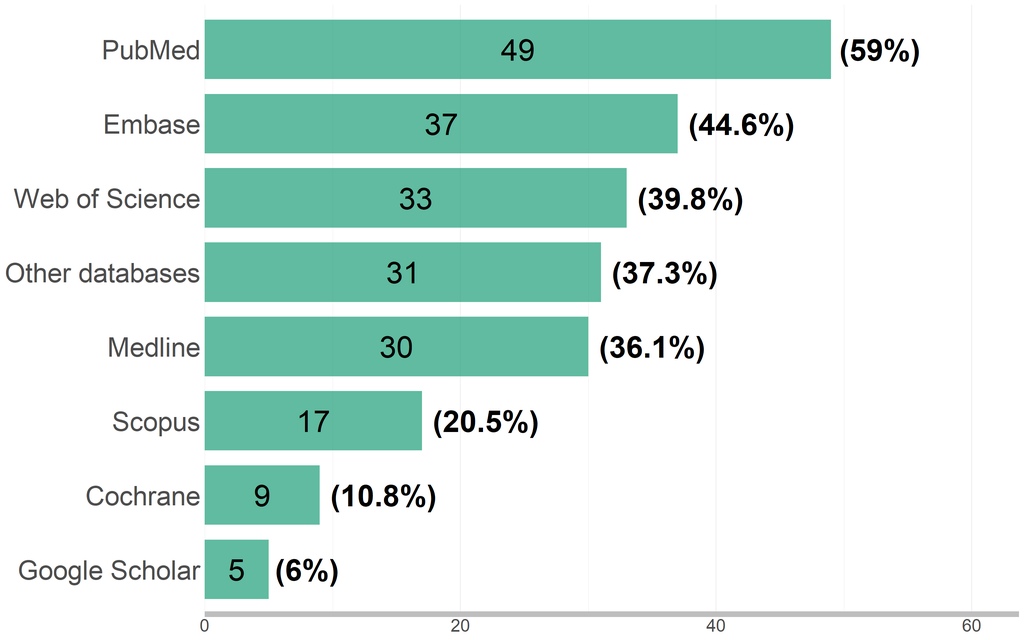

```r
# Calculate the total count for each category
database_count <- sd %>%
  separate_rows(database_search, sep = ",\\s+") %>%
  count(database_search) %>%
  filter(database_search != "NA") %>%
  arrange(desc(n)) %>%
  mutate(database_search = ifelse(n<= 3, "Other databases", as.character(database_search))) %>%
    group_by(database_search) %>%
  summarise(n = sum(n))

# Calculate proportion and percentage for each category
database_pct <- database_count %>%
  mutate(proportion = n / 83, # 83 is number of studies assessed for CEESAT
         percentage = proportion * 100)

# Create the count plot
database_bar <- database_count %>%
  ggplot(aes(x = n, y = reorder(database_search, n), fill = "#1b9e77")) +
  geom_bar(stat = "identity", width = 0.8 , alpha = 0.7) +
  geom_text(aes(label = n, x = n / 2, y = reorder(database_search, n)), hjust = 0.5, size = 12, color = "black") +
  geom_text(data = database_pct, aes(label = paste0("(", round(percentage, 1), "%)"), x = n),
            hjust = -0.1, size = 12, color = "black", fontface = "bold") +
  scale_fill_identity(guide = "none") +
  scale_x_continuous(expand = c(0, 0), limits = c(0, max(database_count$n)*1.3)) +
  labs(title = NULL, x = NULL, y = NULL) +
  organochlorTHEME()

database_bar
```

```r
# ggsave(here("figures", "database_bar.pdf"), width = 16, height = 10, units = "cm", scale = 2, dpi = 800)
# ggsave(here("figures", "database_bar.svg"), width = 16, height = 10, units = "cm", scale = 2, dpi = 800)
```

## Alluvial plot for literature database

Alluvial plot showing the relationship between the Journal Citation Report Category and the scientific literature database used. Filtered for scientific literature database counts greater than or equal to 3.

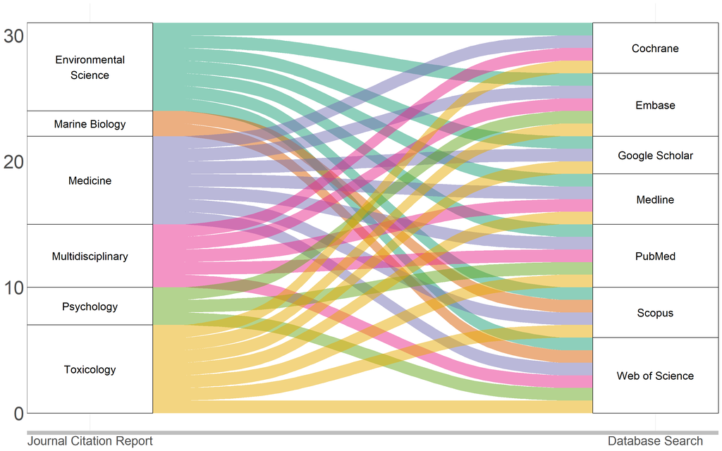

```r
# Rename Environmental Science
sd <- sd %>%
  mutate(Journal_Category_Allocated_Broad = str_replace(Journal_Category_Allocated_Broad, "Environmental Science", "Environmental\nScience"))

# Data Transformation
database_alluvial <- sd %>%
    separate_rows(database_search, sep = ",\\s+") %>%
    group_by(Journal_Category_Allocated_Broad, database_search) %>%
    count(database_search, Journal_Category_Allocated_Broad) %>%
    summarise(freq = n(), .groups = 'drop') %>%
    group_by(database_search) %>%
    filter(sum(freq) >= 3) %>%
    filter(database_search != "NA")

# Create the Alluvial plot
alluvial_database <- database_alluvial %>%
ggplot(aes(y = freq ,axis1 = Journal_Category_Allocated_Broad, axis2 = database_search)) +
  scale_x_discrete(limits = c("Journal Citation Report", "Database Search"), expand = c(.05, .05)) +
  xlab("Variables") +
  ylab("Frequency") +
  geom_alluvium(aes(fill = Journal_Category_Allocated_Broad)) +
  geom_stratum(width = 1/4.5, fill = "white", color = "black") +
  geom_text(stat = "stratum", aes(label = after_stat(stratum)), size = 6) +
  labs(x= "Variables", y = "Frequency", fill = "Journal Category Allocated") +
  scale_fill_brewer(palette = "Dark2") +
  organochlorTHEME()

alluvial_database
```

```r
# ggsave(here("figures", "alluvial_database.pdf"), width = 16, height = 10, units = "cm", scale = 2, dpi = 800)
# ggsave(here("figures", "alluvial_database.jpg"), width = 16, height = 10, units = "cm", scale = 2, dpi = 800)
```

## Software bar plot

Bar plot showing the percentage and total count of software for analysis used in meta-analyses investigating the impacts of organochlorine pesticides. Note that some meta-analyses may contribute to multiple sections if the study involved multiple software. Percentage is showing the proportion of studies.

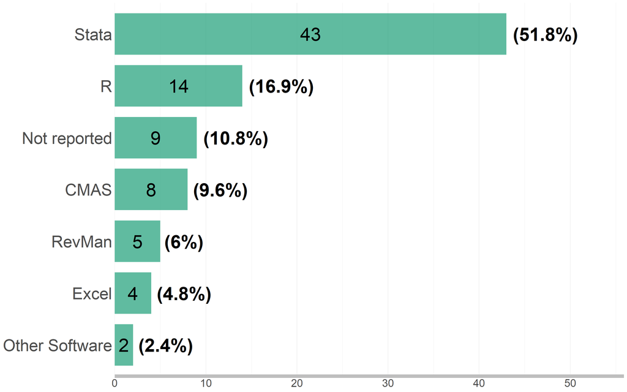

```r
# Calculate the total count for each category
software_count <- sd %>%
  separate_rows(software_analysis, sep = ",\\s+") %>%
  mutate(software_analysis = ifelse(grepl("comprehensive meta-analysis", software_analysis), "CMAS", software_analysis)) %>%
  count(software_analysis) %>%
  filter(software_analysis != "NA") %>%
  arrange(desc(n)) %>%
  mutate(software_analysis = ifelse(n < 2, "Other Software", as.character(software_analysis))) %>%
  group_by(software_analysis) %>%
  summarise(n = sum(n))

# Calculate proportion and percentage for each category
software_pct <- software_count %>%
  mutate(proportion = n / 83,
         percentage = proportion * 100)

# Create the count plot
software_bar <- software_count %>%
  ggplot(aes(x = n, y = reorder(software_analysis, n), fill = "#1b9e77")) +
  geom_bar(stat = "identity", width = 0.8 , alpha = 0.7) +
  geom_text(aes(label = n, x = n / 2, y = reorder(software_analysis, n)), hjust = 0.5, size = 12, color = "black") +
  geom_text(data = software_pct, aes(label = paste0("(", round(percentage, 1), "%)"), x = n),
            hjust = -0.1, size = 12, color = "black", fontface = "bold") +
  scale_fill_identity(guide = "none") +
  scale_x_continuous(expand = c(0, 0), limits = c(0, max(software_count$n)*1.3)) +
  labs(title = NULL, x = NULL, y = NULL) +
  organochlorTHEME()

software_bar
```

```r
# ggsave(here("figures", "software_bar.pdf"), width = 16, height = 10, units = "cm", scale = 2, dpi = 800)
# ggsave(here("figures", "software_bar.svg"), width = 16, height = 10, units = "cm", scale = 2, dpi = 800)
```

## Alluvial plot for software

Alluvial plot showing the relationship between the Journal Citation Report Category and the software used for analysis.

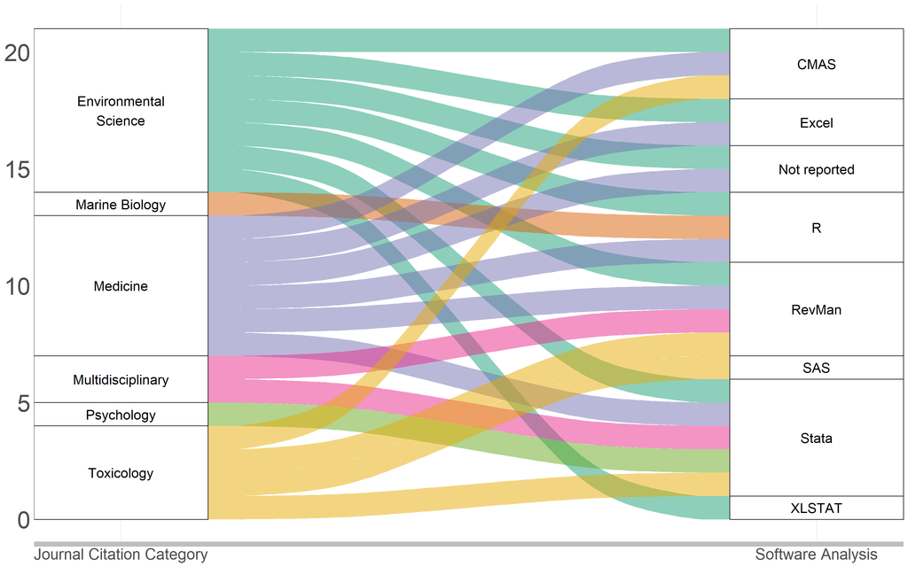

```r
# Data Transformation
software_analysis_alluvial <- sd %>%
    separate_rows(software_analysis, sep = ",\\s+") %>%
    separate_rows(Journal_Category_Allocated_Broad, sep = "/\\s+") %>%
  mutate(software_analysis = ifelse(grepl("comprehensive meta-analysis", software_analysis), "CMAS", software_analysis)) %>%
  mutate(software_analysis = ifelse(grepl("not reported", software_analysis), "no software reported", software_analysis))  %>%
    filter(!is.na(software_analysis)) %>%
    group_by(Journal_Category_Allocated_Broad, software_analysis) %>%
    count(software_analysis, Journal_Category_Allocated_Broad) %>%
    summarise(freq = n(), .groups = 'drop') %>%
    group_by(software_analysis)

# Create the Alluvial plot for Software Analysis
alluvial_software <- software_analysis_alluvial %>%
  ggplot(aes(y = freq ,axis1 = Journal_Category_Allocated_Broad, axis2 = software_analysis)) +
  scale_x_discrete(limits = c("Journal Citation Category", "Software Analysis"), expand = c(.05, .05)) +
  xlab("Variables") +
  geom_alluvium(aes(fill = Journal_Category_Allocated_Broad)) +
  geom_stratum(width = 1/4, fill = "white", color = "black") +
  geom_text(stat = "stratum", aes(label = after_stat(stratum)), size = 6) +
  labs(x= "Variables", y = "Frequency", fill = "Journal Category Allocated") +
  scale_fill_brewer(palette = "Dark2") +
  organochlorTHEME()

alluvial_software
```

```r
# ggsave(here("figures", "alluvial_software.pdf"), width = 16, height = 10, units = "cm", scale = 2, dpi = 800)
# ggsave(here("figures", "alluvial_software.jpg"), width = 16, height = 10, units = "cm", scale = 2, dpi = 800)
```

## Effect size bar

Bar plot showing the percentage and total count of effect size calculation types used in meta-analyses investigating the impacts of organochlorine pesticides. Note that some meta-analyses may contribute to multiple sections if the study involved multiple effect size calculations. The “Other effect sizes” category includes all effect sizes with a count of 2 or less. Percentage is showing the proportion of studies.

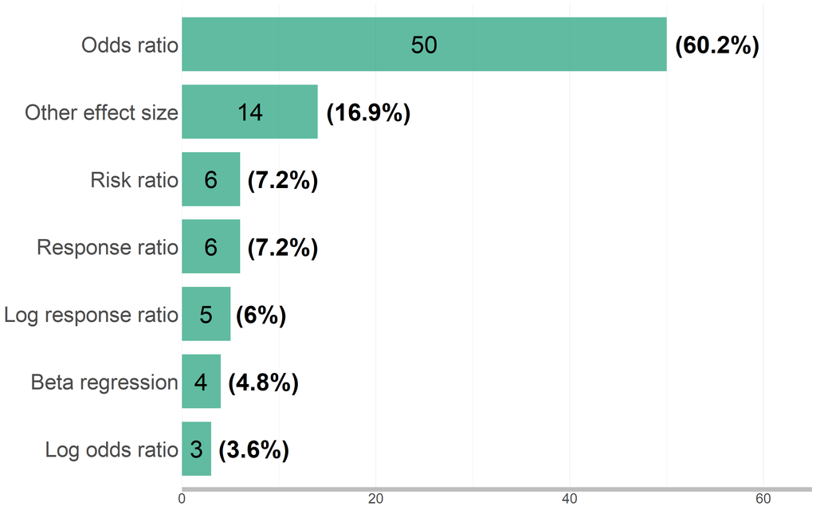

```r
# Calculate the total count for each category
effectsize_count <- sd %>%
  separate_rows(effect_size, sep = ",\\s+") %>%
  count(effect_size) %>%
  filter(effect_size != "NA") %>%
  mutate(effect_size = ifelse(n<= 2, "Other effect size", as.character(effect_size))) %>%
  group_by(effect_size) %>%
  summarise(n = sum(n))

# Calculate proportion and percentage for each category
effectsize_pct <- effectsize_count %>%
  mutate(proportion = n / 83,
         percentage = proportion * 100)

# Create the count plot
effect_bar <-  effectsize_count %>%
  ggplot(aes(x = n, y = reorder(effect_size, n), fill = "#1b9e77")) +
  geom_bar(stat = "identity", width = 0.8 , alpha = 0.7) +
  geom_text(aes(label = n, x = n / 2, y = reorder(effect_size, n)), hjust = 0.5, size = 12, color = "black") +
  geom_text(data = effectsize_pct, aes(label = paste0("(", round(percentage, 1), "%)"), x = n),
            hjust = -0.1, size = 12, color = "black", fontface = "bold") +
  scale_fill_identity(guide = "none") +
  scale_x_continuous(expand = c(0, 0), limits = c(0, max(effectsize_count$n)*1.3)) +
  labs(title = NULL, x = NULL, y = NULL) +
  organochlorTHEME()

effect_bar
```

```r
# ggsave(here("figures", "effect_bar.pdf"), width = 16, height = 10, units = "cm", scale = 2, dpi = 800)
# ggsave(here("figures", "effect_bar.svg"), width = 16, height = 10, units = "cm", scale = 2, dpi = 800)
```

## Alluvial plot for effect size estimates

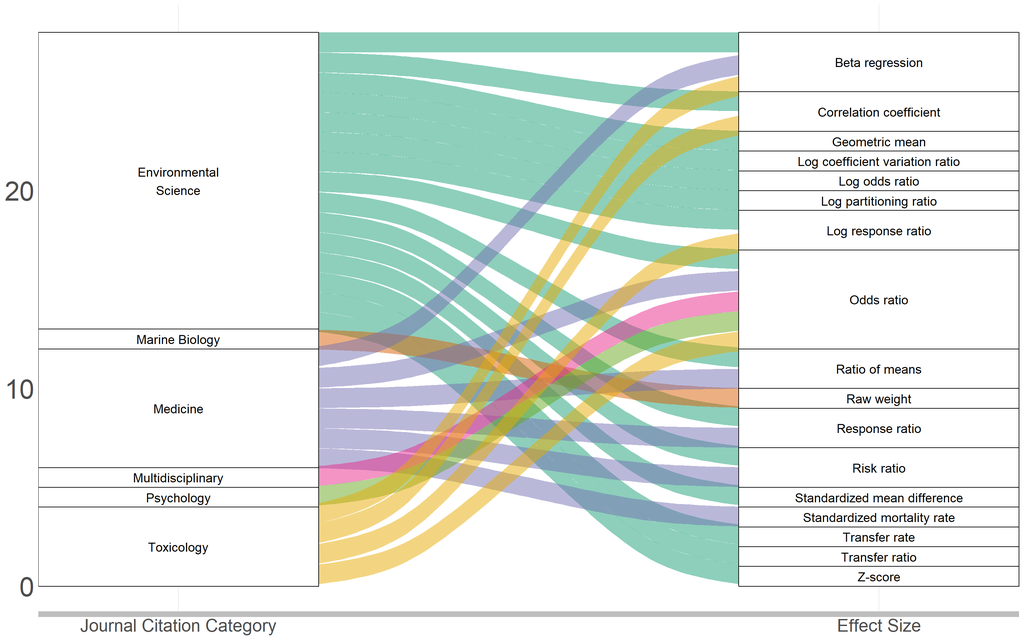

```r
# Data Transformation
effectsize_alluvial <- sd %>%
    separate_rows(effect_size, sep = ",\\s+") %>%
    separate_rows(Journal_Category_Allocated_Broad, sep = "/\\s+") %>%
    filter(!grepl("no category found", Journal_Category_Allocated_Broad, ignore.case = TRUE)) %>%
    filter(!is.na(effect_size)) %>%
    group_by(Journal_Category_Allocated_Broad, effect_size) %>%
    count(effect_size, Journal_Category_Allocated_Broad) %>%
    summarise(freq = n(), .groups = 'drop') %>%
    group_by(effect_size)


# Create the Alluvial plot
alluvial_effect <- effectsize_alluvial %>%
ggplot(aes(y = freq ,axis1 = Journal_Category_Allocated_Broad, axis2 = effect_size)) +
  scale_x_discrete(limits = c("Journal Citation Category", "Effect Size"), expand = c(.05, .05)) +
  xlab("Variables") +
  geom_alluvium(aes(fill = Journal_Category_Allocated_Broad)) +
  geom_stratum(width = 1/2.5, fill = "white", color = "black") +
  geom_text(stat = "stratum", aes(label = after_stat(stratum)), size = 5) +
  theme_minimal() +
  labs(x= "Variables", y = "Frequency", fill = "Journal Category Allocated") +
  scale_fill_brewer(palette = "Dark2") +
  organochlorTHEME()

alluvial_effect
```

```r
# ggsave(here("figures", "alluvial_effect.pdf"), width = 16, height = 10, units = "cm", scale = 2, dpi = 800)
# ggsave(here("figures", "alluvial_effect.jpg"), width = 16, height = 10, units = "cm", scale = 2, dpi = 800)
```

## Bar plot for visualisation method

Bar plot showing the percentage and total count of visualization methods used in meta-analyses investigating the impacts of organochlorine pesticides. Note that some meta-analyses may contribute to multiple sections if the study involved the use of multiple visualization methods.

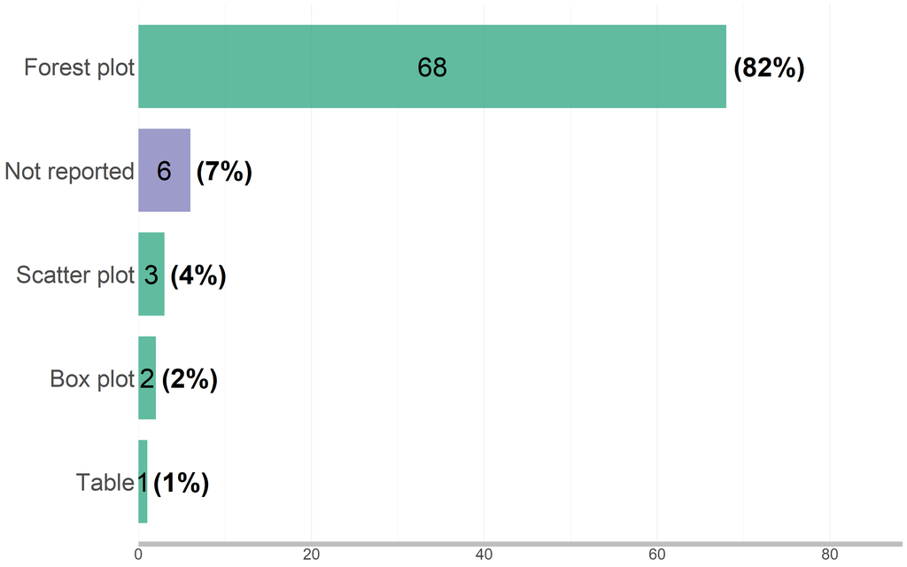

```r
# Calculate the total count for each category
visualization_count <- sd %>%
  separate_rows(visualization_method, sep = ",\\s+") %>%
  count(visualization_method) %>%
  filter(visualization_method != "NA") %>%
    group_by(visualization_method) %>%
  summarise(n = sum(n))

# Calculate proportion and percentage for each category
visualization_pct <- visualization_count %>%
  mutate(proportion = n / 83,
         percentage = proportion * 100)

# Create the count plot
bar_vis <- visualization_count %>%
  ggplot(aes(x = n, y = reorder(visualization_method, n), fill = ifelse(grepl("Not reported", visualization_method), "#7370b3", "#1b9e77"))) +
  geom_bar(stat = "identity", width = 0.8 , alpha = 0.7) +
  geom_text(aes(label = n, x = n / 2, y = reorder(visualization_method, n)), hjust = 0.5, size = 12, color = "black") +
  geom_text(data = visualization_pct, aes(label = paste0("(", round(percentage, 0), "%)"), x = n),
            hjust = -0.1, size = 12, color = "black", fontface = "bold") +
  scale_fill_identity(guide = "none") +
  scale_x_continuous(expand = c(0, 0), limits = c(0, max(visualization_count$n)*1.3)) +
  labs(title = NULL, x = NULL, y = NULL) +
  organochlorTHEME()

bar_vis
```

```r
# ggsave(here("figures", "bar_vis.pdf"), width = 16, height = 10, units = "cm", scale = 2, dpi = 800)
# ggsave(here("figures", "bar_vis.svg"), width = 16, height = 10, units = "cm", scale = 2, dpi = 800)
```

## Alluvial plot for visualisation method

Alluvial plot showing the relationship between the Journal Citation Report Category and visualization method.

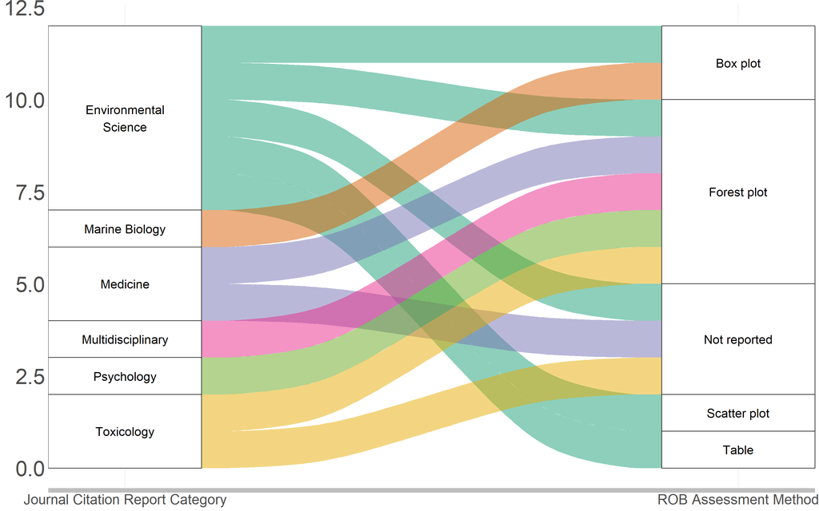

```r
# Data Transformation
visualization_alluvial <- sd %>%
    separate_rows(visualization_method, sep = ",\\s+") %>%
    filter(!is.na(visualization_method)) %>%
    separate_rows(Journal_Category_Allocated_Broad, sep = "/\\s+") %>%
    group_by(Journal_Category_Allocated_Broad, visualization_method) %>%
    count(visualization_method, Journal_Category_Allocated_Broad) %>%
    summarise(freq = n(), .groups = 'drop') %>%
    group_by(visualization_method)


# Create the Alluvial plot
alluvial_vis <- visualization_alluvial %>%
ggplot(aes(y = freq ,axis1 = Journal_Category_Allocated_Broad, axis2 = visualization_method)) +
  scale_x_discrete(limits = c("Journal Citation Report Category", "ROB Assessment Method"), expand = c(.05, .05)) +
  xlab("Variables") +
  geom_alluvium(aes(fill = Journal_Category_Allocated_Broad)) +
  geom_stratum(width = 1/4, fill = "white", color = "black") +
  geom_text(stat = "stratum", aes(label = after_stat(stratum)), size = 6) +
  labs(x= "Variables", y = "Frequency", fill = "Journal Category Allocated") +
  scale_fill_brewer(palette = "Dark2") +
  organochlorTHEME()

alluvial_vis
```

```r
# ggsave(here("figures", "alluvial_vis.pdf"), width = 16, height = 10, units = "cm", scale = 2, dpi = 800)
# ggsave(here("figures", "alluvial_vis.jpg"), width = 16, height = 10, units = "cm", scale = 2, dpi = 800)
```

## Bar plot for risk of bias

Bar plot showing the percentage and total count of risk of bias tests used in meta-analyses investigating the impacts of organochlorine pesticides. Note that some meta-analyses may contribute to multiple sections if the study involved the use of multiple risk of bias tests.

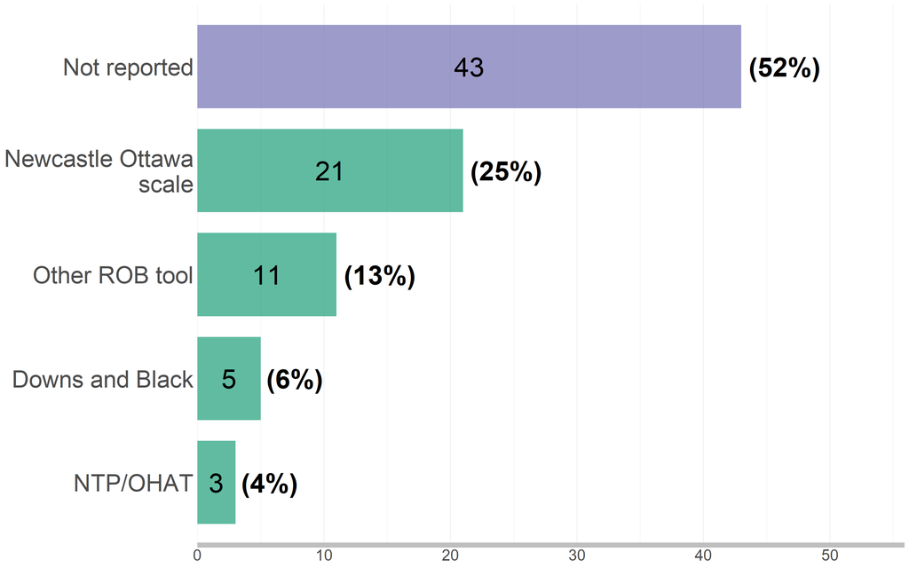

```r
# Calculate the total count for each category
rob_method_count <- sd %>%
  separate_rows(rob_assessment_method, sep = ",\\s+") %>%
  count(rob_assessment_method) %>%
  filter(rob_assessment_method != "NA") %>%
  mutate(rob_assessment_method = ifelse(n <= 2, "Other ROB tool", as.character(rob_assessment_method))) %>%
  mutate(rob_assessment_method = ifelse(grepl("Newcastle Ottawa scale", rob_assessment_method),
                                        "Newcastle Ottawa\nscale", rob_assessment_method)) %>%
  group_by(rob_assessment_method) %>%
  summarise(n = sum(n))

# Calculate proportion and percentage for each category
rob_method_pct <- rob_method_count %>%
  mutate(proportion = n / 83,
         percentage = proportion * 100)

# Create the count plot
bar_risk_of_bias <- rob_method_count %>%
  ggplot(aes(x = n, y = reorder(rob_assessment_method, n),
             fill = ifelse(grepl("Not reported", rob_assessment_method), "#7370b3", "#1b9e77"))) +
  geom_bar(stat = "identity", width = 0.8 , alpha = 0.7) +
  geom_text(aes(label = n, x = n/2, y = reorder(rob_assessment_method, n)),
            hjust = 0.5, size = 12, color = "black") +
  geom_text(data = rob_method_pct, aes(label = paste0("(", round(percentage, 0), "%)"), x = n),
            hjust = -0.1, size = 12, color = "black", fontface = "bold") +
  scale_fill_identity(guide = "none") +
  scale_x_continuous(expand = c(0, 0), limits = c(0, max(rob_method_count$n)*1.3)) +
  labs(title = NULL, x = NULL, y = NULL) +
  organochlorTHEME()

bar_risk_of_bias
```

```r
# ggsave(here("figures", "bar_plot_risk_of_bias.pdf"), width = 16, height = 10, units = "cm", scale = 2, dpi = 800)
# ggsave(here("figures", "bar_plot_risk_of_bias.svg"), width = 16, height = 10, units = "cm", scale = 2, dpi = 800)
```

## Alluvial plot for risk of bias

Alluvial plot showing the relationship between the Journal Citation Report Category and risk of bias methodology.

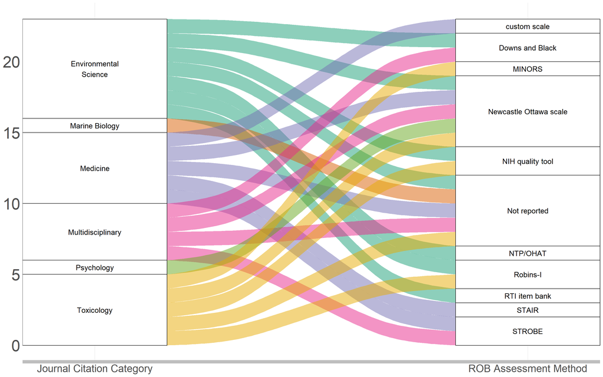

```r
# Data Transformation
robmethod_alluvial <- sd %>%
  separate_rows(rob_assessment_method, sep = ",\\s+") %>%
  filter(!is.na(rob_assessment_method)) %>%
  separate_rows(Journal_Category_Allocated_Broad, sep = "/\\s+") %>%
  group_by(Journal_Category_Allocated_Broad, rob_assessment_method) %>%
  count(rob_assessment_method, Journal_Category_Allocated_Broad) %>%
  summarise(freq = n(), .groups = 'drop') %>%
  group_by(rob_assessment_method)

# Create the Alluvial plot
alluvial_risk_of_bias <- robmethod_alluvial %>%
  ggplot(aes(y = freq ,axis1 = Journal_Category_Allocated_Broad, axis2 = rob_assessment_method)) +
  scale_x_discrete(limits = c("Journal Citation Category", "ROB Assessment Method"), expand = c(.05, .05)) +
  xlab("Variables") +
  geom_alluvium(aes(fill = Journal_Category_Allocated_Broad)) +
  geom_stratum(width = 1/3, fill = "white", color = "black") +
  geom_text(stat = "stratum", aes(label = after_stat(stratum)), size = 5) +
  labs(x= "Variables", y = "Frequency", fill = "Journal Category Allocated") +
  scale_fill_brewer(palette = "Dark2") +
  organochlorTHEME()

alluvial_risk_of_bias
```

```r
# ggsave(here("figures", "alluvial_plot_risk_of_bias.pdf"), width = 16, height = 10, units = "cm", scale = 2, dpi = 800)
# ggsave(here("figures", "alluvial_plot_risk_of_bias.jpg"), width = 16, height = 10, units = "cm", scale = 2, dpi = 800)
```

## Bar plot for bias visualizations

Bar plot showing the percentage and total count of bias visualizations used in meta-analyses investigating the impacts of organochlorine pesticides. Note that some meta-analyses may contribute to multiple sections if the study involved the use of multiple bias visualizations.

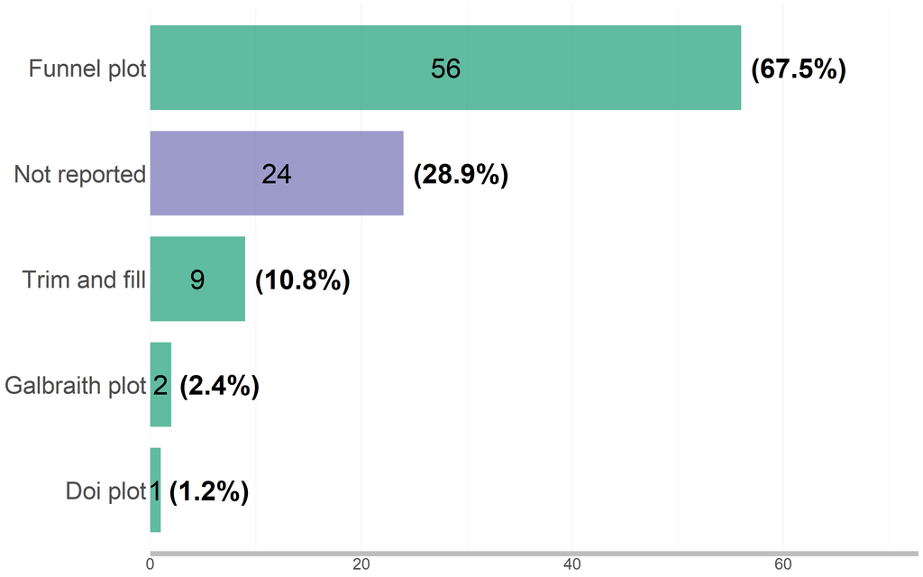

```r
# Calculate the total count for each category
bias_visualization_count <- sd %>%
  separate_rows(bias_assessment_visualization, sep = ",\\s+") %>%
  count(bias_assessment_visualization) %>%
  filter(bias_assessment_visualization != "NA") %>%
  group_by(bias_assessment_visualization) %>%
  summarise(n = sum(n))

# Calculate proportion and percentage for each category
bias_visualization_pct <- bias_visualization_count %>%
  mutate(proportion = n / 83,
         percentage = proportion * 100)

# Create the count plot
bar_bias_visualization <- bias_visualization_count %>%
  ggplot(aes(x = n, y = reorder(bias_assessment_visualization, n),
             fill = ifelse(grepl("Not reported", bias_assessment_visualization), "#7370b3", "#1b9e77"))) +
  geom_bar(stat = "identity", width = 0.8 , alpha = 0.7) +
  geom_text(aes(label = n, x = n/2, y = reorder(bias_assessment_visualization, n)),
            hjust = 0.5, size = 12, color = "black") +
  geom_text(data = bias_visualization_pct, aes(label = paste0("(", round(percentage, 1), "%)"), x = n),
            hjust = -0.1, size = 12, color = "black", fontface = "bold") +
  scale_fill_identity(guide = "none") +
  scale_x_continuous(expand = c(0, 0), limits = c(0, max(bias_visualization_count$n)*1.3)) +
  labs(title = NULL, x = NULL, y = NULL) +
  organochlorTHEME()

bar_bias_visualization
```

```r
# ggsave(here("figures", "bar_plot_bias_visualization.pdf"), width = 16, height = 10, units = "cm", scale = 2, dpi = 800)
# ggsave(here("figures", "bar_plot_bias_visualization.svg"), width = 16, height = 10, units = "cm", scale = 2, dpi = 800)
```

## Alluvial plot for bias visualization method

Alluvial plot showing the relationship between the Journal Citation Report Category and bias visualization method.

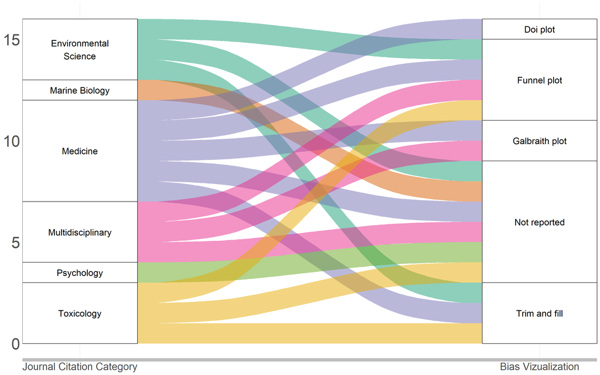

```r
# Data Transformation
bias_vizualisation_alluvial <- sd %>%
    separate_rows(bias_assessment_visualization, sep = ",\\s+") %>%
    separate_rows(Journal_Category_Allocated_Broad, sep = "/\\s+") %>%
    filter(!is.na(bias_assessment_visualization)) %>%
    group_by(Journal_Category_Allocated_Broad, bias_assessment_visualization) %>%
    count(bias_assessment_visualization, Journal_Category_Allocated_Broad) %>%
    summarise(freq = n(), .groups = 'drop') %>%
    group_by(bias_assessment_visualization)

# Create the Alluvial plot
alluvial_bias_visualization <- bias_vizualisation_alluvial %>%
  ggplot(aes(y = freq, axis1 = Journal_Category_Allocated_Broad, axis2 = bias_assessment_visualization)) +
  scale_x_discrete(limits = c("Journal Citation Category", "Bias Vizualization"), expand = c(.05, .05)) +
  xlab("Variables") +
  geom_alluvium(aes(fill = Journal_Category_Allocated_Broad)) +
  geom_stratum(width = 1/4, fill = "white", color = "black") +
  geom_text(stat = "stratum", aes(label = after_stat(stratum)), size = 6) +
  labs(x= "Variables", y = "Frequency", fill = "Journal Category Allocated") +
  scale_fill_brewer(palette = "Dark2") +
  organochlorTHEME()

alluvial_bias_visualization
```

```r
# ggsave(here("figures", "alluvial_plot_bias_visualization.pdf"), width = 16, height = 10, units = "cm", scale = 2, dpi = 800)
# ggsave(here("figures", "alluvial_plot_bias_visualization.svg"), width = 16, height = 10, units = "cm", scale = 2, dpi = 800)
```

## Circular treemap for existing methodological approaches

A circular treemap showing the counts of each methodological item in existing meta-analysis investigating the impacts of organochlorine pesticides

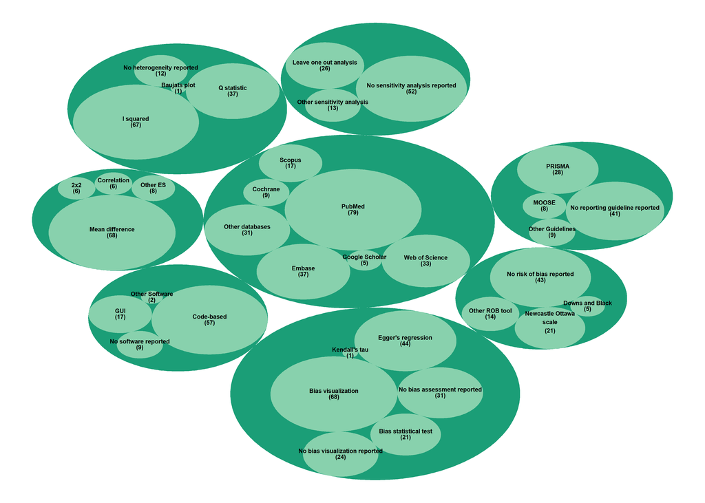

```r
# Grouping "Medline" and "Pubmed" under "PubMed" and summing the counts
database_count <- database_count %>%
  mutate(database_search = if_else(database_search %in% c("Medline", "Pubmed"), "PubMed", database_search)) %>%
  group_by(database_search) %>%
  summarise(n = sum(n))

# Splitting, grouping, and summing different categories of effect sizes
effectsize_count <- sd %>%
  separate_rows(effect_size, sep = ",\\s+") %>%
  count(effect_size) %>%
  filter(effect_size != "NA") %>%
  group_by(effect_size) %>%
  summarise(n = sum(n))

effectsize_count <- effectsize_count %>%
  mutate(effect_size = if_else(effect_size %in% c("Beta regression", "Correlation coefficient"), "Correlation", effect_size)) %>%
  mutate(effect_size = if_else(effect_size %in% c("Odds ratio", "Response ratio", "Standardized mean difference", "Log partitioning ratio", "Log odds ratio", "Ratio of means", "Log response ratio"), "Mean difference", effect_size)) %>%
  mutate(effect_size = if_else(effect_size %in% c("Risk ratio"), "2x2", effect_size)) %>%
  mutate(effect_size = if_else(effect_size %in% c("Raw weight", "Geometric mean", "Maternal transfer ratio", "Standardized mortality rate", "Transfer rate","Transfer ratio", "Z-score", "Log coefficient variation ratio"), "Other ES", effect_size)) %>%
  group_by(effect_size) %>%
  summarise(n = sum(n))

# Categorizing software as either "Code-based software" or "GUI" and summing the counts
software_count <- software_count %>%
  mutate(software_analysis = if_else(software_analysis %in% c("Stata", "R", "SAS"), "Code-based", software_analysis)) %>%
  mutate(software_analysis = if_else(software_analysis %in% c("CMAS", "Excel", "RevMan", "XLSTAT"), "GUI", software_analysis)) %>%
  mutate(software_analysis = if_else(software_analysis %in% c("Not reported"), "No software reported", software_analysis)) %>%
  group_by(software_analysis) %>%
  summarise(n = sum(n))

# Grouping heterogeneity assessment methods and summing the counts
heterogeneity_count <- heterogeneity_count %>%
  mutate(heterogeneity_assessment_method = if_else(heterogeneity_assessment_method %in% c("Tau square"), "I squared", heterogeneity_assessment_method)) %>%
  mutate(heterogeneity_assessment_method = if_else(heterogeneity_assessment_method %in% c("Chi square"), "Q statistic", heterogeneity_assessment_method)) %>%
  mutate(heterogeneity_assessment_method = if_else(heterogeneity_assessment_method %in% c("Not reported"), "No heterogeneity reported", heterogeneity_assessment_method)) %>%
  group_by(heterogeneity_assessment_method) %>%
  summarise(n = sum(n))

# Grouping bias assessment methods with count <= 3 under "Other BA" and summing the counts
bias_method_count <- bias_method_count %>%
  mutate(bias_assessment_method = if_else(bias_assessment_method %in% c("Egger's regression test", "Fail safe", "Begg's test", "Kendall's tau statistic"),"Bias statistical test", bias_assessment_method)) %>%
    mutate(bias_assessment_method = if_else(bias_assessment_method %in% c("Not reported"),"No bias assessment reported", bias_assessment_method)) %>%
  group_by(bias_assessment_method) %>%
  summarise(n = sum(n))

# Grouping sensitivity analysis methods and summing the counts
sensitivity_count <-  sensitivity_count %>%
  mutate(sensitivity_analysis_method = if_else(n<= 8, "Other sensitivity analysis", as.character(sensitivity_analysis_method))) %>%
   mutate(sensitivity_analysis_method = if_else(sensitivity_analysis_method %in% c("Not reported"), "No sensitivity analysis reported",sensitivity_analysis_method)) %>%
  group_by(sensitivity_analysis_method) %>%
  summarise(n = sum(n))

# Grouping risk of bias assessment methods with count <= 3 under "Other ROB" and summing the counts
rob_method_count <-  rob_method_count %>%
  mutate(rob_assessment_method = if_else(n<= 3, "Other ROB tool", as.character(rob_assessment_method))) %>%
    mutate(rob_assessment_method = if_else(rob_assessment_method %in% c("Not reported"), "No risk of bias reported", rob_assessment_method)) %>%
  group_by(rob_assessment_method) %>%
  summarise(n = sum(n))

# Grouping visualization methods with count <= 3 under "Other Viz" and summing the counts
visualization_count <- visualization_count %>%
   mutate(visualization_method = if_else(n<= 3, "Other Viz", as.character(visualization_method))) %>%
  mutate(visualization_method = if_else(visualization_method %in% c("Not reported"), "No vizualization reported", visualization_method)) %>%
  group_by(visualization_method) %>%
  summarise(n = sum(n))

# Grouping reporting standards types with count <= 2 under "Other guideline" and summing the counts
reporting_guide_count <- reporting_guide_count %>%
  mutate(reporting_standards_type = ifelse(n<= 2, "Other guideline", as.character(reporting_standards_type))) %>%
  mutate(reporting_standards_type = ifelse(reporting_standards_type %in% c("Not reported"), "No reporting guideline reported",reporting_standards_type)) %>%
  group_by(reporting_standards_type) %>%
  summarise(n = sum(n))

# Grouping bias assessment visualization types and summing the counts
bias_visualization_count <- bias_visualization_count %>%
  mutate(bias_assessment_visualization = if_else(bias_assessment_visualization %in% c("Doi plot", "Trim and fill", "Funnel plot", "Galbraith plot"), "Bias visualization", bias_assessment_visualization)) %>%
  mutate(bias_assessment_visualization = if_else(bias_assessment_visualization %in% c("Not reported"), "No bias visualization reported", bias_assessment_visualization)) %>%
  group_by(bias_assessment_visualization) %>%
  summarise(n = sum(n))

# Combine the data frames and unite the methodology types
df <- bind_rows(
  database_count %>% mutate(methodology_type = 'Database Search'),
  effectsize_count %>% mutate(methodology_type = 'Effect Size'),
  software_count %>%  mutate(methodology_type = "Software"),
  heterogeneity_count %>% mutate(methodology_type = "Heterogeneity"),
  sensitivity_count %>% mutate(methodology_type = "Sensitivity_Analysis"),
  bias_method_count %>%  mutate(methodology_type = "Bias Assessment"),
  rob_method_count %>% mutate(methodology_type = "Risk  of Bias"),
 # visualization_count %>% mutate(methodology_type = "Visualization"),
  reporting_guide_count %>%  mutate(methodology_type = "Reporting Guide"),
  bias_visualization_count %>%  mutate(methodology_type = "Bias Assessment")
) %>%
 unite(methodology_type_specific,
       database_search,
       effect_size,
       software_analysis,
       heterogeneity_assessment_method,
       sensitivity_analysis_method,
       bias_assessment_method,
       rob_assessment_method,
      # visualization_method,
       reporting_standards_type,
       bias_assessment_visualization,
       remove = TRUE, na.rm = TRUE)

# Preparing the edges dataframe for creating the graph
edges <- df %>%
  rename(from = methodology_type, to = methodology_type_specific, size = n) %>%
  select(c(from,to,size)) %>%
  as.data.frame()

# Preparing the vertices dataframe for creating the graph
vertices <- df  %>%
  rename(name = methodology_type_specific, size = n) %>%
  select(c(name,size)) %>%
  as.data.frame()

# Appending unique 'from' values to vertices and their corresponding summed sizes
vertices[(nrow(edges)+1):(nrow(edges)+length(unique(edges$from))),1] <- unique(edges$from)
N <- aggregate(edges$size, list(edges$from), FUN=sum)
vertices[(nrow(edges)+1):(nrow(edges)+length(unique(edges$from))),2] <- N$x

# Creating a graph object from the edges and vertices dataframes
mygraph <- graph_from_data_frame(edges, vertices = vertices)

# Plotting the graph using a 'circlepack' layout
circular_treemap_methods <- ggraph(mygraph, layout = 'circlepack', weight = size) +
    geom_node_circle(aes(fill = as.factor(depth)), color = NA) +
    scale_fill_manual(values = c("#1b9e77", "#88D1AD")) +
    geom_node_text(aes(label = name, filter = leaf, size = 10), vjust = -0.3, fontface = "bold") +
    geom_node_text(aes(label = paste0("(", size, ")"), filter = leaf, size = 10), vjust = 1, fontface = "bold") +
    theme_void() +
    theme(legend.position = "none")

circular_treemap_methods
```

```r
# ggsave(here("figures", "circular_treemap_methods.pdf"), width = 18, height = 15, units = "cm", scale = 2, dpi = 800)
# ggsave(here("figures", "circular_treemap_methods.jpg"), width = 18, height = 15, units = "cm", scale = 2, dpi = 800)
```

## Donut plot for confound analysis

```r
# Remove NA values and count Yes/No
confound_data <- sd %>%
  filter(!is.na(confound_analysis)) %>%
  count(confound_analysis) %>%
  mutate(percentage = n / sum(n) * 100)

# Donut Plot with a hole
donut_plot <- ggplot(confound_data, aes(x = 2, y = percentage, fill = confound_analysis)) +
  geom_bar(stat = "identity", width = 1, color = "white") +
  coord_polar(theta = "y", start = 0) +
  geom_text(
    aes(label = paste0(round(percentage, 1), "%")),
    position = position_stack(vjust = 0.5),
    size = 5,
    fontface = "bold",
    color = "white"
  ) +
  scale_fill_manual(values = c("yes" = "#d95f02", "no" = "#1b9e77")) +  # Custom colors
  labs(fill = NULL) +  # Remove legend title
  theme_void() +
  theme(
    legend.position = "none",  # Remove legend
    plot.title = element_text(size = 16, face = "bold", hjust = 0.5)
  ) +
  xlim(0.5, 2.5)  # Creates the hole in the middle

# Save figures
# ggsave(here("figures", "donut_confound.pdf"), plot = donut_plot, width = 8, height = 8, units = "cm", dpi = 800)
# ggsave(here("figures", "donut_confound.svg"), plot = donut_plot, width = 8, height = 8, units = "cm", dpi = 800)
```

# Section 2

To explore the various characteristics of the organochlorine pesticides literature such as the pesticides used, the impacts elicited in response and the subjects that were investigated.

## Bar plot for organochlorine pesticides investigated

A bar plot showing the percentage and total count of total of pesticides investigate in meta-analysis investigating the impacts of organochlorine pesticides. Note: some meta-analysis may contribute to multiple sections if the study involves multiple organochlorine pesticides. Filtered for pesticide counts greater than 6.

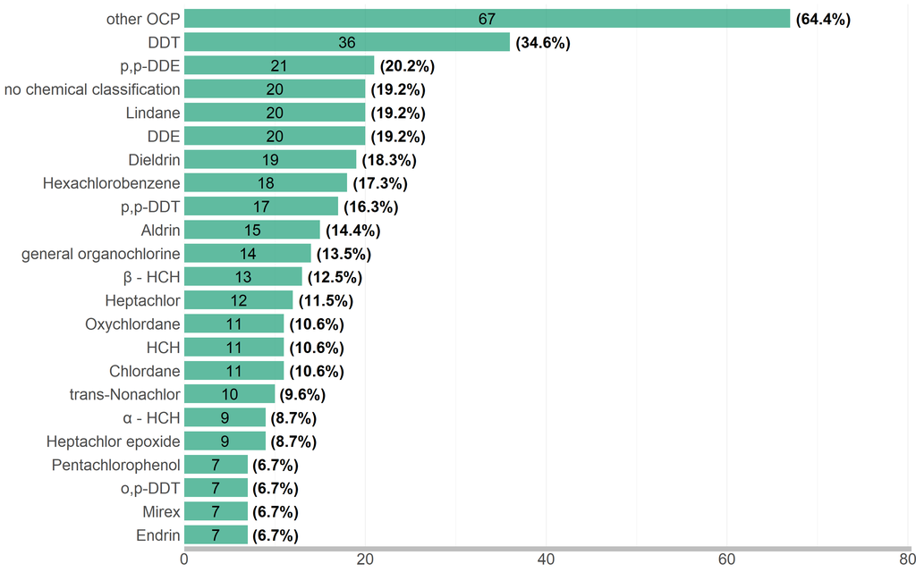

```r
# Function to replace long OCP names with abbreviations
replace_ocp <- function(df) {
  df %>%
    mutate(ocp = case_when(
      # HCH related replacements
      grepl("Hexachlorocyclohexane \\(HCH\\)", ocp, ignore.case = TRUE) ~ "HCH",
      grepl("alpha-Hexachlorocyclohexane \\(alpha-HCH\\)", ocp, ignore.case = TRUE) ~ "α - HCH",
      grepl("beta-Hexachlorocyclohexane \\(beta-HCH\\)", ocp, ignore.case = TRUE) ~ "β - HCH",
      grepl("gamma-Hexachlorocyclohexane \\(gamma-HCH\\)", ocp, ignore.case = TRUE) ~ "Lindane",
      # DDT related replacements
      grepl("Dichlorodiphenyltrichloroethane \\(DDT\\)", ocp, ignore.case = TRUE) ~ "DDT",
      grepl("p,p-Dichlorodiphenyltrichloroethane \\(p,p-DDT\\)", ocp, ignore.case = TRUE) ~ "p,p-DDT",
      grepl("o,p-Dichlorodiphenyltrichloroethane \\(o,p-DDT\\)", ocp, ignore.case = TRUE) ~ "o,p-DDT",
      # DDD related replacements
      grepl("Dichlorodiphenyldichloroethane \\(DDD\\)", ocp, ignore.case = TRUE) ~ "DDD",
      grepl("p,p-Dichlorodiphenyldichloroethane \\(p,p-DDD\\)", ocp, ignore.case = TRUE) ~ "p,p-DDD",
      grepl("o,p-Dichlorodiphenyldichloroethane \\(o,p-DDD\\)", ocp, ignore.case = TRUE) ~ "o,p-DDD",
      # DDE related replacements
      grepl("Dichlorodiphenyldichloroethylene \\(DDE\\)", ocp, ignore.case = TRUE) ~ "DDE",
      grepl("p,p-Dichlorodiphenyldichloroethylene \\(p,p-DDE\\)", ocp, ignore.case = TRUE) ~ "p,p-DDE",
      grepl("o,p-Dichlorodiphenyldichloroethylene \\(o,p-DDE\\)", ocp, ignore.case = TRUE) ~ "o,p-DDE",
      TRUE ~ ocp  # no change for any others
    ))
}

# Transform the data
ocp_count <- ocp %>%
  separate_rows(ocp, sep = ",\\s+") %>%
  replace_ocp() %>%
  count(ocp) %>%
  filter(!is.na(ocp)) %>%  # filter out NA
  arrange(desc(n)) %>%
  mutate(ocp = ifelse(n <= 6, "other OCP", as.character(ocp))) %>%
  group_by(ocp) %>%
  summarise(n = sum(n))

# Calculate the proportion and percentage of each OCP
ocp_pct <- ocp_count %>%
  mutate(proportion = n / 104,
         percentage = proportion * 100)

# Create the count plot for OCPs
bar_plot_ocp <- ocp_count %>%
  ggplot(aes(x = n, y = reorder(ocp, n), fill = "#1b9e77")) +
  geom_bar(stat = "identity", width = 0.8, alpha = 0.7) +
  geom_text(aes(label = n, x = n / 2, y = reorder(ocp, n)),
            hjust = 0.5, size = 7, color = "black") +
  geom_text(data = ocp_pct,
            aes(label = paste0("(", round(percentage, 1), "%)"), x = n),
            hjust = -0.1, size = 7, color = "black", fontface = "bold") +
  scale_fill_identity(guide = "none") +
  scale_x_continuous(name = "Article Count", expand = c(0, 0), limits = c(0, max(ocp_count$n)*1.2)) +
  labs(title = NULL, x = NULL, y = NULL) +
  organochlorTHEME() +
  theme(axis.text.y = element_text(size = 20))

bar_plot_ocp
```

```r
# ggsave(here("figures", "bar_plot_pesticide_investigation.pdf"),
#        plot = bar_plot_ocp, width = 25, height = 15, units = "cm", scale = 2, dpi = 800)
# ggsave(here("figures", "bar_plot_pesticide_investigation.svg"),
#        plot = bar_plot_ocp, width = 25, height = 15, units = "cm", scale = 2, dpi = 800)
```